# Basic Skills in Bootstrap using R

## 11.2 Parametric bootstrap

For parametric bootstrap we need to make an assumption about $F(x,y,\theta)$ under the null hypothesis. Let us assume that the joint distribution of $x$ and $y$ is a bivariate normal distribution. Since the null hypothesis states that $x$ and $y$ are independent, it implies that the marginal distributions of $x$ and $y$ are two independent normal distributions (so $\rho=0$). Hence, under $H_{0}$, $x \sim N(\mu_x,\sigma^{2}_x)$ and $y \sim N(\mu_y,\sigma^{2}_y)$ . We cannot resample from these distributions since the parameters are unknown and therefore we will replace them with the plug-in estimator and resample from
$$\hat{F}_x=N(\hat{\mu}_x,\hat{\sigma}^{2}_x), \hat{F}_y=N(\hat{\mu}_y,\hat{\sigma}^{2}_y).$$

The pulg-in estimators for $\hat{F}_x$ and $\hat{F}_y$

```r
MLx<-mean(x)
MLy<-mean(y)
Sigx<-sqrt(var(x))
Sigy<-sqrt(var(y))
```

A parametric bootstrap is implemented using the follwoing code:

```r
n<-length(x)
B<-1000
coeff.boot<-c(1:B)
for(b in 1:B)
{
x.boot<- rnorm(n,MLx,Sigx)
y.boot<- rnorm(n,MLy,Sigy)
coeff.boot[b]<-cor(x.boot,y.boot)
}
```

The distribution of the test statistic under $H_{0}$.

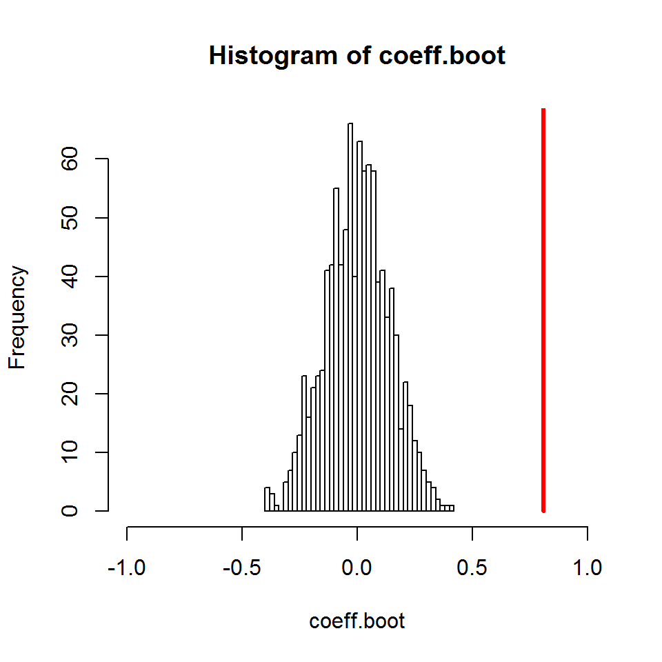

```r
hist(coeff.boot,nclass=50,xlim=c(-1,1))
lines(c(rho,rho),c(0,500),col=2,lwd=3)
```

```r
(1+sum(abs(coeff.boot)>rho))/(B+1)
```

```
## [1] 0.000999001
```

# 12 Premutaions test

The nonparametric bootstrap is based on an algorithm of sampling with replacement. An alternative is to resample without replacement. Consider the two samples problem in which we would like to test the null hypothesis
$$H_{0}:\mu_x=\mu_y.$$
Let ($x_1,\dots,x_n$_ and ($y_{1},\dots,y_m$) the samples from the two populations and the combined sample $z=(x,y)$

The non parametric bootstrap precedure without replacent for testing $H_{0}$ is as follows

- Simulate $B$ samples of size $m+n$ without replacement from $z$. The first $n$ are considered as  
  observations $x^{\star}$ and the remaining $m$ as observations $y^{\star}$.
- Calculate the test statistic values $t(z^*)_1, \ldots, t(z^*)_b, \ldots, t(z^*)_B$, independently under the null hypothesis model,
  $$t(z^*)_{b}=\frac{\bar{x^{*}}-\bar{y^{\star}}}{\bar{\sigma^{\star}}\sqrt{1/m+1/n}},\;\;b=1,\ldots,B.$$
  Its conditional null distribution is determined by that of $z_1, \dots, z_n$ , which is uniform over all permutations of random selection of $n$ observations from the vector $z_1, \dots, z_{n+m}$. In this way, the conditional P-value
  $$p_{con} = P(T \geq t|S=s , H_0),$$
  can be computed exactly. Alternatively, we can generate $B$ such random permutations and compute the Monte Carlo $P$-value $p_{mc}$.

## 12.1 YouTube tutorial: Permutation tests in R

A tutorial by Ian Dworkin about permutation test in R. The tutorial is focused on a One-Way ANOVA with two groups using a resampling procedure without replacement. This example I equivalent to a permutation test for two samples t-test. Within the context of this course, this example is similar to the examples discussed in the chapter about linear model . For the tutorial click here: [YTBootstrap 8](https://www.youtube.com/watch?v=ZiQdzwB12Pk).

## 12.2 Premutaions test for the mouse data

The data and boxplot for the mouse data are shwon below.

```r
x<-c(94,197,16,38,99,141,23)
y<-c(52,104,146,10,51,30,40,27,46)
z<-c(x,y)
z
```

```
##  [1]  94 197  16  38  99 141  23  52 104 146  10  51  30  40  27  46
```

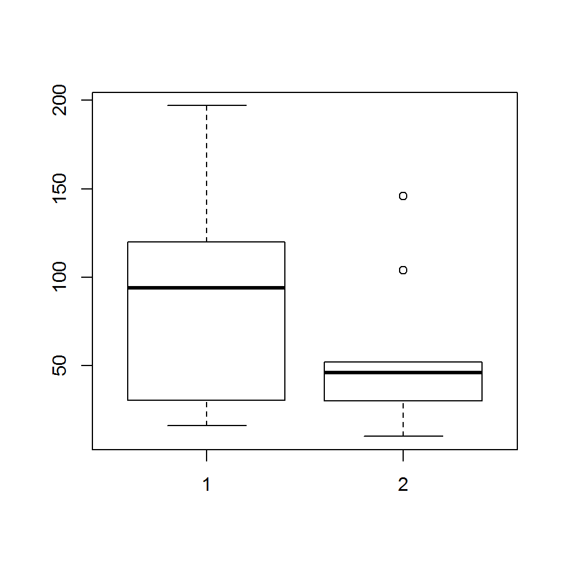

```r
n<-length(x)
m<-length(y)
boxplot(x,y)
```

Recall that a classical two samples t-test leads to the following results:

```r
t.test(x,y,alternative="greater",var.equal=TRUE)
```

```
##
##  Two Sample t-test
##
## data:  x and y
## t = 1.1208, df = 14, p-value = 0.1406
## alternative hypothesis: true difference in means is greater than 0
## 95 percent confidence interval:
##  -17.50517       Inf
## sample estimates:
## mean of x mean of y
##  86.85714  56.22222
```

```r
t.obs<-t.test(x,y,alternative="greater",var.equal=TRUE)$statistic
```

For the permutation test, we first need to define the combine sample ($z$):

```r
z<-c(x,y)
r.x<-rep("x",n)
r.y<-rep("y",m)
r.x<-c(r.x,r.y)
data.frame(sort(z),r.x[order(z)])
```

```
##    sort.z. r.x.order.z..
## 1       10             y
## 2       16             x
## 3       23             x
## 4       27             y
## 5       30             y
## 6       38             x
## 7       40             y
## 8       46             y
## 9       51             y
## 10      52             y
## 11      94             x
## 12      99             x
## 13     104             y
## 14     141             x
## 15     146             y
## 16     197             x
```

The permutation procedure is implemented using a non parametric bootstrap in which the resampling is done without replacement (i.e., using the argument: $replace=FALSE$).

```r
B<-10000
v.boot<-t.boot<-c(1:B)
for(b in 1:B)
{
z.boot<-sample(z,size=n+m,replace=FALSE)
v.boot[b]<-var(z.boot)
x.boot<-z.boot[1:n]
y.boot<-z.boot[(n+1):(n+m)]
t.boot[b]<-t.test(x.boot,y.boot,alternative="greater",var.equal=TRUE)$statistic
}
```

Distribution of the permutation test statistic and Monte Carlo p value.

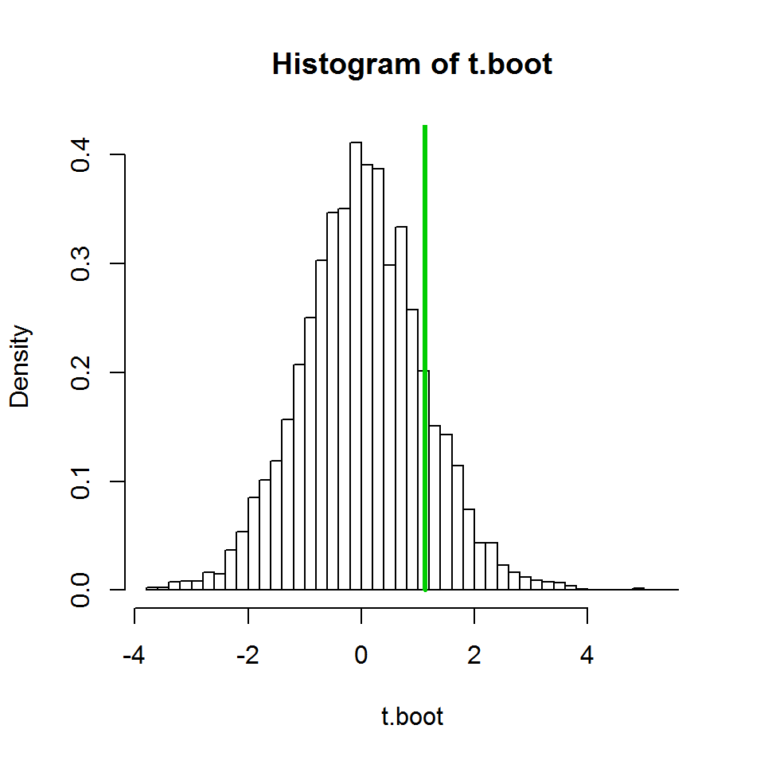

```r
hist(t.boot,nclass=50,probability=TRUE)
lines(c(t.obs,t.obs),c(0,10),col=3,lwd=3)
```

```r
(1+sum(t.boot>t.obs))/(B+1)
```

```
## [1] 0.139886
```

# 13 Binary data

## 13.1 The setting

Let $x_{1},\dots,x_{n}$ and $y_{1},\dots,y_{m}$ two samples from the populations: $x_{i}\sim B(\pi_{1},n)$ and $y_{i}\sim B(\pi_{2},m)$. Both $\pi_{1}$ and $\pi_{2}$ are unknown parameters. We wish to test the null hypothesis
$$H_0 : \pi_1 = \pi_2.$$
We use a two sample t test statistic for proporions
$$t=\frac{\hat{\pi}_1 - \hat{\pi}_2}{\sqrt{\pi(1-\pi) \left(\frac{1}{n} +
\frac{1}{m}\right)}} \sim N(0;1).$$
Here, $\hat{\pi}_{1}$ and $\hat{\pi}_{2}$ are the plug-in estimators for the two unknown proportions. Since $\pi$ is unknown we estimate it by the pool proporion given by

$$\hat{\pi} = \frac{n \hat{\pi}_1 + m \hat{\pi}_2}{n+m},$$

as an estimate for the proportion under $H_{0}$,

$$t=\frac{\hat{\pi}_1 - \hat{\pi}_2}{\sqrt{\hat{\pi}(1-\hat{\pi}) \left(\frac{1}{n} +
\frac{1}{m}\right)}} \sim N(0;1).$$

## 13.2 Example: Relationship between aspirin use and myocardial infarction (heart attacks).

A five-year randomized study testing whether regular intake of aspirin reduces mortality from cardiovascular disease. Every other day, the male physicians participating in the study took either one aspirin tablet or a placebo. Data, in a table format, are given below.

```r
phs <- matrix(c(189,10845,104,10933),byrow=TRUE,ncol=2)
dimnames(phs) <- list(Group=c("Placebo","Aspirin"),MI=c("Yes","No"))
phs
```

```
##          MI
## Group     Yes    No
##   Placebo 189 10845
##   Aspirin 104 10933
```

### 13.2.1 Classical test for $H_{0}:\pi_{1}=\pi_{2}$.

To calculate the difference between the two proportions we define the following R objects:

```r
n.P<-189+10845
n.A<-104+10933
Placebo<-c(rep(1,189),rep(0,10845))
Aspirin<-c(rep(1,104),rep(0,10933))
P.Placebo<-189/(189+10845)
P.Aspirin<-104/(104+10933)
```

$\hat{\pi}_{1}-\hat{\pi}_{2}$:

```r
P.Placebo-P.Aspirin
```

```
## [1] 0.007706024
```

The pool proportion, $\hat{\pi}$:

```r
P.tot<-(189+104)/(189+10845+104+10933)
P.tot
```

```
## [1] 0.01327534
```

Test statistics and p value:

```r
z<-(P.Placebo-P.Aspirin)/sqrt(P.tot*(1-P.tot)*(1/n.P+1/n.A))
z
```

```
## [1] 5.001388
```

```r
1-pnorm(z,0,1)
```

```
## [1] 2.845948e-07
```

### 13.2.2 Parametric bootstrap test for $H_{0}\pi_{1}=\pi_{2}$.

For parametric bootstrap, we assume that , under $H_{0}$, $x_{i}\sim B(\pi,n)$ and $y_{i}\sim B(\pi,m)$. Since $\pi$ is unknown we use the pool samples proportion $\hat{\pi}$. The parametric bootstrap is implemented below.Note that here, $\hat{F}_{x}=B(\hat{\pi},n)$.

```r
B<-1000
z.b<-c(1:B)
for(i in 1:B)
{
S1<-sum(rbinom(n.P,1,P.tot))
P.P.b<-S1/(189+10845)
S2<-sum(rbinom(n.A,1,P.tot))
P.A.b<-S2/(104+10933)
P.tot.b<-(S1+S2)/(n.P+n.A)
z.b[i]<-(P.P.b-P.A.b)/sqrt(P.tot.b*(1-P.tot.b)*(1/n.P+1/n.A))
}
```

The ditribution of the test statistic unfer $H_{0}$

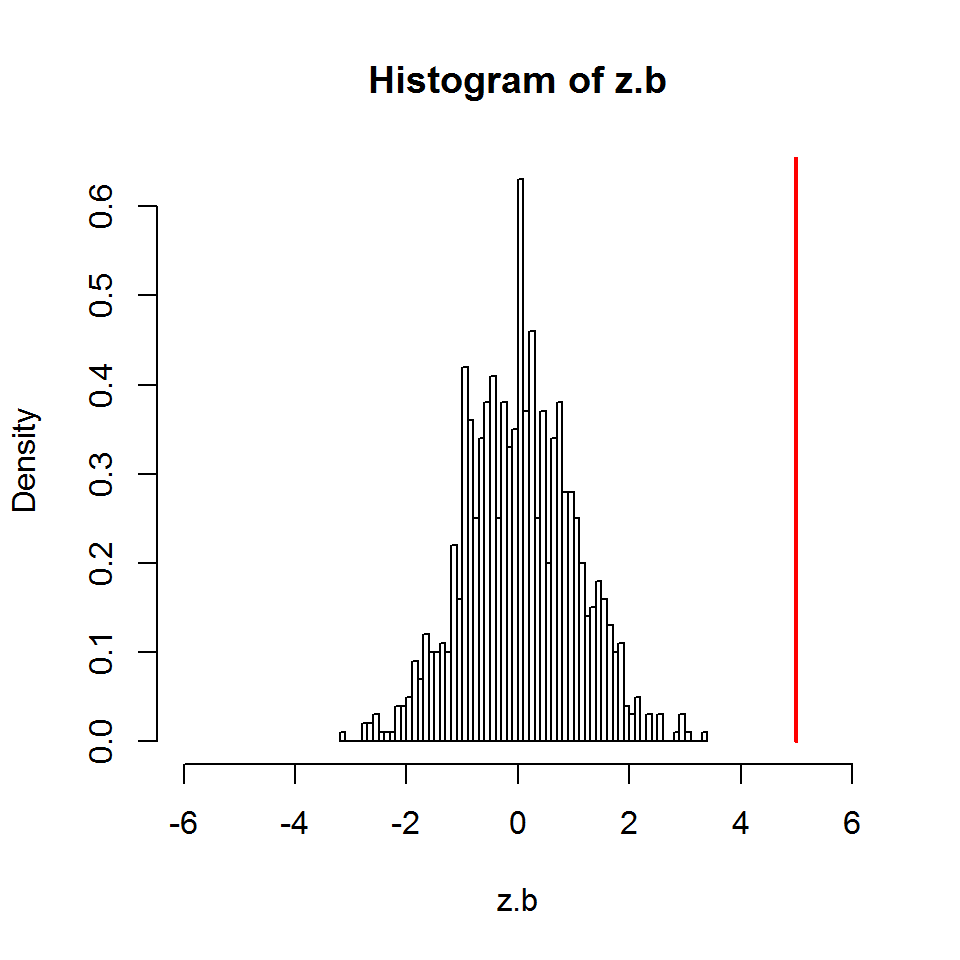

```r
hist(z.b,nclass=50,xlim=c(-6,6),probability=TRUE)
lines(c(z,z),c(0,100),col=2,lwd=2)
```

The p-value

```r
(1+sum(abs(z.b)>abs(z)))/(B+1)
```

```
## [1] 0.000999001
```

### 13.2.3 Non parametric bootstrap test for $H_{0}\pi_{1}=\pi_{2}$.

For non parametric bootstrap, we define a new vector ($z.i$) for the joint sample:

```r
z.i<-c(Placebo,Aspirin)
nz<-length(z.i)
nz
```

```
## [1] 22071
```

A non-parametric bootstrap procedure consists of resampling $B$ bootstrap samples with replacement from the joint sample, which is the same algorithm that was used for the two sample problems.

```r
B<-1000
z.b<-c(1:B)
for(i in 1:B)
{
z.boot<-sample(z.i,size=nz,replace =TRUE)
x.boot<-z.boot[1:n.P]
y.boot<-z.boot[(n.P+1):nz]
S1<-sum(x.boot)
P.P.b<-S1/(189+10845)
S2<-sum(y.boot)
P.A.b<-S2/(104+10933)
P.tot.b<-(S1+S2)/(n.P+n.A)
z.b[i]<-(P.P.b-P.A.b)/sqrt(P.tot.b*(1-P.tot.b)*(1/n.P+1/n.A))
}
```

The distribution of the test statistic under $H_{0}$

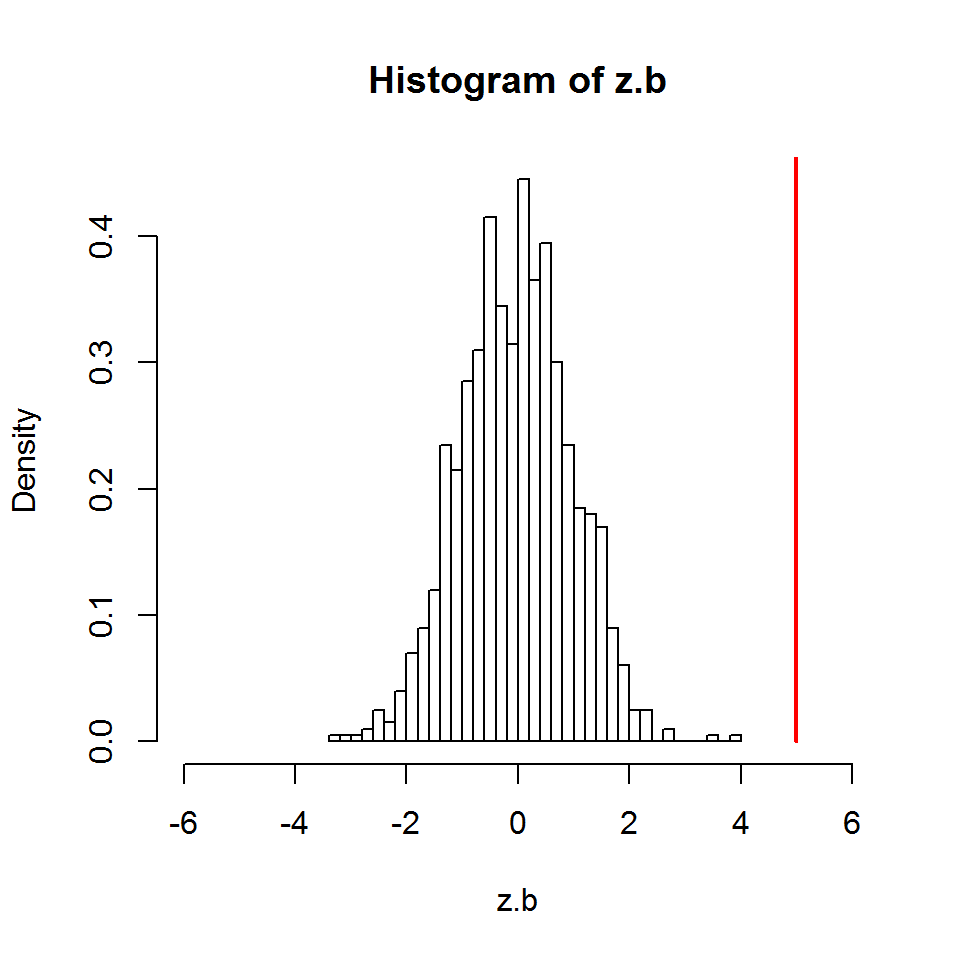

```r
hist(z.b,nclass=50,xlim=c(-6,6),probability=TRUE)
lines(c(z,z),c(0,100),col=2,lwd=2)
```

Monte carlo p value.

```r
(1+sum(abs(z.b)>abs(z)))/(B+1)
```

```
## [1] 0.000999001
```

### 13.2.4 Permutaion test for $H_{0}\pi_{1}=\pi_{2}$.

A Permutation procedure is similar to the non-parametric bootstrap procedure above but now we resample $B$ bootstrap samples WITHOUT replacement from the joint sample (we use the argument: $replace =FALSE$).

```r
z.b<-c(1:B)
z.i<-c(Placebo,Aspirin)
nz<-length(z.i)
nz
```

```
## [1] 22071
```

```r
for(i in 1:B)
{
z.boot<-sample(z.i,size=nz,replace =FALSE)
x.boot<-z.boot[1:n.P]
y.boot<-z.boot[(n.P+1):nz]
S1<-sum(x.boot)
P.P.b<-S1/(189+10845)
S2<-sum(y.boot)
P.A.b<-S2/(104+10933)
P.tot.b<-(S1+S2)/(n.P+n.A)
z.b[i]<-(P.P.b-P.A.b)/sqrt(P.tot.b*(1-P.tot.b)*(1/n.P+1/n.A))
}
```

The distribution of the test statistic under $H_{0}$

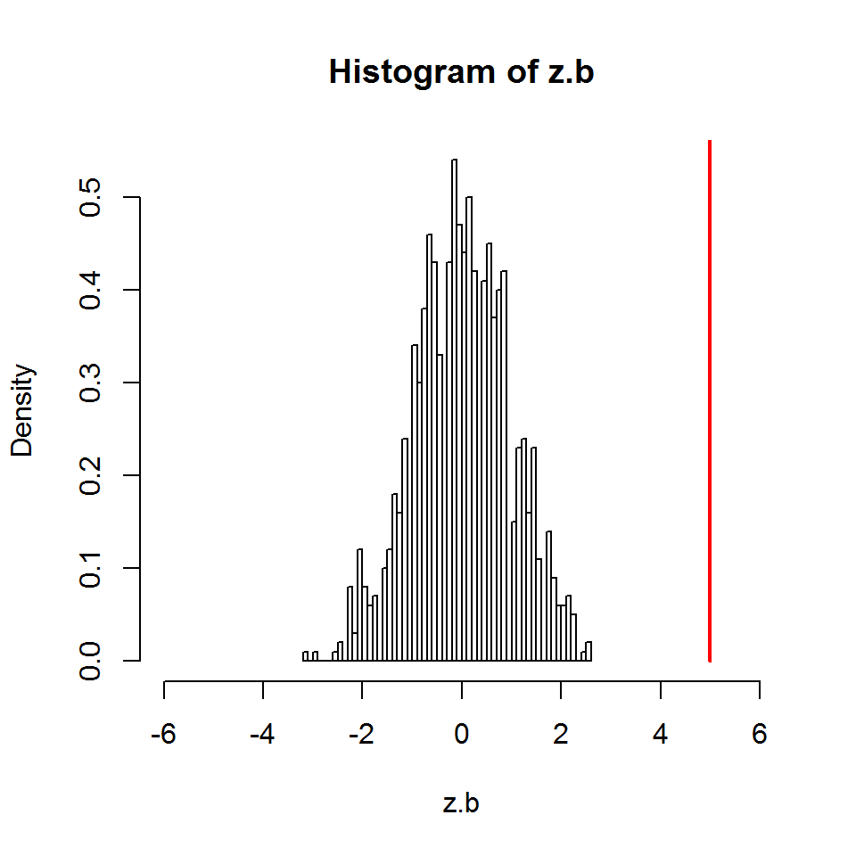

```r
hist(z.b,nclass=50,xlim=c(-6,6),probability=TRUE)
lines(c(z,z),c(0,100),col=2,lwd=2)
```

Monte carlo p value.

```r
(1+sum(abs(z.b)>abs(z)))/(B+1)
```

```
## [1] 0.000999001
```

# 14 Linear models

## 14.1 The setting

Consider data $(X_i,y_i)$, $i = 1, \ldots, n$, where $X_i$ is a column-vector containing the values of the explanatory variables. In parametric linear regression, we assume the following model, for $i= 1, \ldots, n$,
$$y_i = x_i^T \beta + \varepsilon_i,$$
where $\varepsilon_i \sim {\cal N}(0,\sigma^2)$ (independent). The regression coefficients $\beta$ can be estimated using the ordinary least squares method or by a more robust method like e.g. least trimmed squares regression.

In this chapter we discuss three bootstrap procedures allied to linear regression models:

- Non parametric bootstrap.
- Semi-parametric bootstrap
- Parametric bootstrap.

## 14.2 YouTube tutorial: bootstrap application for linear regression.

A YouTube Ian Dworkin presents a bootstrap application for multiple linear regression using the $lm$ function in R. The tutorial is focused on estimation and C.Is. See [YTBootstrap 9](https://www.youtube.com/watch?v=ydtOTctg5So&t=5s).

## 14.3 Non parametric bootstrap

In this chapter we discuss three bootstrap procedures allied to linear regression models:

- Non parametric bootstrap.
- Semi-parametric bootstrap
- Parametric bootstrap.

As usual, we do not need to make any distributional assumption if we implement a non-parametric procedure to estimate the unknown parameters in the linear model defined above. Note that bootstrap procedures for inference will be discussed later. Since our main focus in this section is estimation and confidence intervaks we need to keep the correlation structure in the data fixed. Therefore, the resampling procedure consists of resampling pairs of observations. We apply the following bootstrap: Let the observed data be$z_i = (x_i, y_i)\ ,\ i = 1, \ldots, n$ and let $x$ be a specific point of interest. We apply the following bootstrap:

*Take $B$ resamples of size $n$
$$\begin{array}{ccc}
z_1^\ast(1),& \ldots,& z_n^*(1)\\
z_1^\ast(2),& \ldots,& z_n^* (2)\\
\vdots& & \\
z_1^\ast (B),& \ldots,& z_n^* (B)
\end{array}$$

*For each $b = 1, \ldots, B$ fit the model

$$y^{*}_{i}=\beta_{0}+\beta_{1} x_{i}+\varepsilon_i,$$

and estimate the unknown parameters in the models

$$\beta^{*}_{1}\dots,\beta^{*}_{B}$$
* Use the above bootstrap replicates for $\beta$ to estimate the standard error, confidence intervals, distribution etc.

### 14.3.1 Example: the hormone data

The hormone data contains information about the amount in milligrams of anti-inflammatory hormone remaining in 27 devices after a certain number of hours (hrs) of wear. The data consists of two variables:

- Hormone level (response)
- Hours (predictor) The data are shown in the Figure below

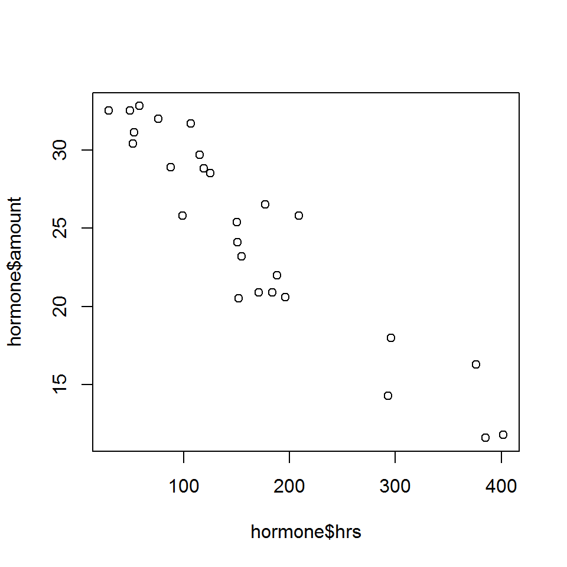

```r
plot(hormone$hrs,hormone$amount)
```

#### 14.3.1.1 Linear regression model

We fit a linear regreesion model with hours as predictor

```r
n<-length(hormone$amount)
fit.lm<-lm(hormone$amount~hormone$hrs)
summary(fit.lm)
```

```
##
## Call:
## lm(formula = hormone$amount ~ hormone$hrs)
##
## Residuals:
##     Min      1Q  Median      3Q     Max
## -4.9357 -1.7282 -0.0229  1.7388  3.7323
##
## Coefficients:
##              Estimate Std. Error t value Pr(>|t|)
## (Intercept) 34.167528   0.867197   39.40  < 2e-16 ***
## hormone$hrs -0.057446   0.004464  -12.87 1.58e-12 ***
## ---
## Signif. codes:  0 '***' 0.001 '**' 0.01 '*' 0.05 '.' 0.1 ' ' 1
##
## Residual standard error: 2.378 on 25 degrees of freedom
## Multiple R-squared:  0.8688, Adjusted R-squared:  0.8636
## F-statistic: 165.6 on 1 and 25 DF,  p-value: 1.584e-12
```

```r
beta0<-summary(fit.lm)$coeff[1,1]
beta1<-summary(fit.lm)$coeff[2,1]
sigma<-2.378
```

Parameter estimates are equal to

```r
c(beta0,beta1)
```

```
## [1] 34.1675282 -0.0574463
```

Data and predicated model

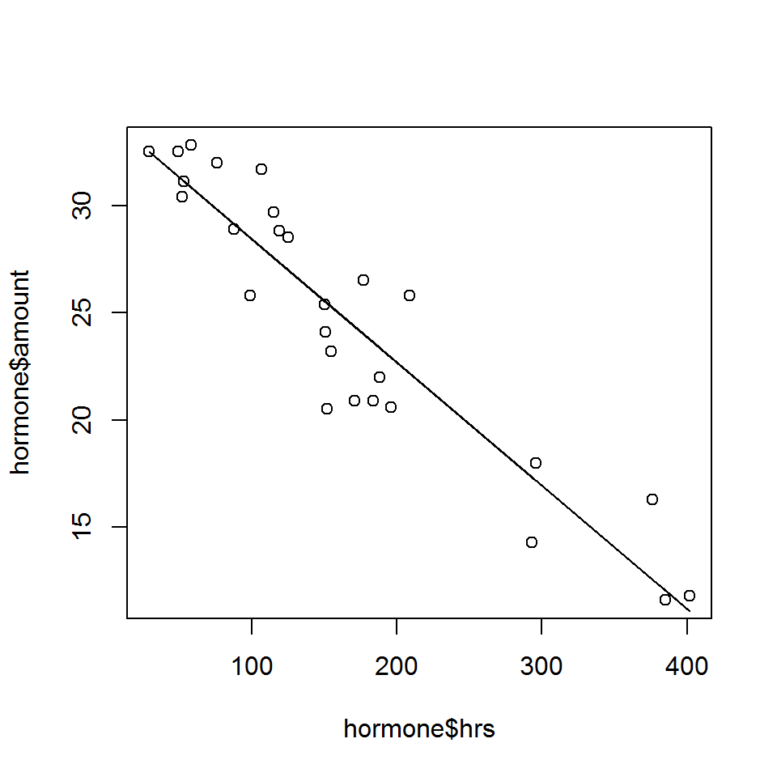

```r
plot(hormone$hrs,hormone$amount)
lines(hormone$hrs,fit.lm$fit)
```

### 14.3.2 Non parametric bootstrap for the hormone data - estimation and C.Is

To implement a non-parametric bootstrap procedure we need to resample pairs. This can be done using an index vector.

```r
index<-c(1:n)
index
```

```
##  [1]  1  2  3  4  5  6  7  8  9 10 11 12 13 14 15 16 17 18 19 20 21 22 23 24 25 26 27
```

A non parametric bootstrap

```r
B<-10000
beta0.b<-beta1.b<-c(1:B)
for (i in 1:B)
{
index.b<-sample(index,n,replace=TRUE)
hormone.b<-hormone[index.b,]
fit.lm.b<-lm(hormone.b$amount~hormone.b$hrs)
beta0.b[i]<-summary(fit.lm.b)$coeff[1,1]
beta1.b[i]<-summary(fit.lm.b)$coeff[2,1]
}
```

Distribution of the bootstrap replicates.

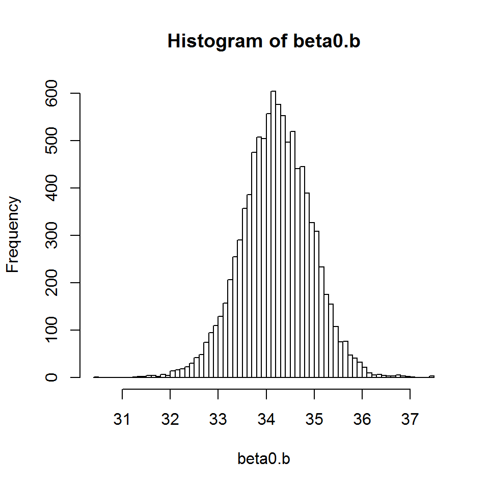

```r
hist(beta0.b,nclass=50)
```

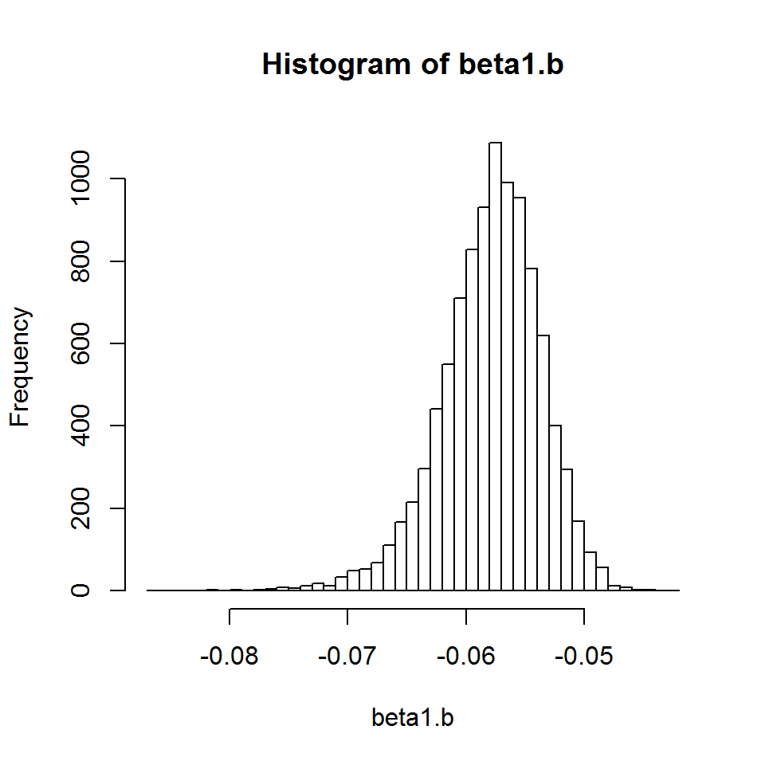

```r
hist(beta1.b,nclass=50)
```

$95\%$ C.Is for $\beta_{0}$ and $\beta_{1}$.

```r
quantile(beta0.b,probs=c(0.025,0.975))
```

```
##     2.5%    97.5%
## 32.74937 35.61445
```

```r
quantile(beta1.b,probs=c(0.025,0.975))
```

```
##        2.5%       97.5%
## -0.06734592 -0.05054579
```

### 14.3.3 Non parametric bootstrap for the hormone data - inference

```r
B<-10000
beta0.b<-beta1.b<-c(1:B)
for (i in 1:B)
{
hormone.b<-sample(hormone$amount,n,replace=TRUE)
fit.lm.b<-lm(hormone.b~hormone$hrs)
beta0.b[i]<-summary(fit.lm.b)$coeff[1,1]
beta1.b[i]<-summary(fit.lm.b)$coeff[2,1]
}
```

The distribution of the parameter estimate under $H_{0}$:

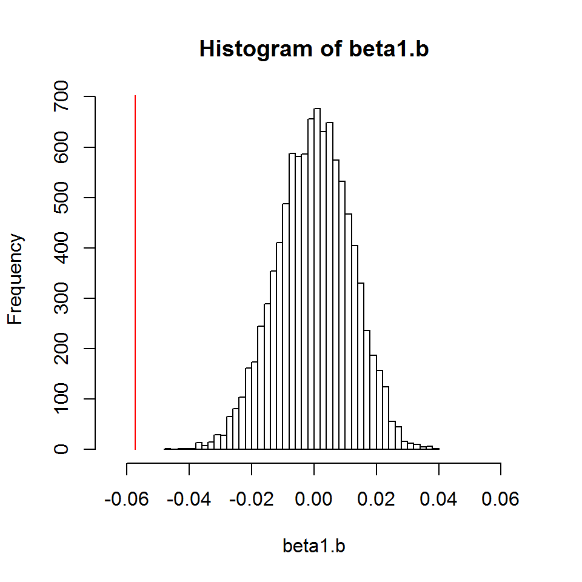

```r
hist(beta1.b,nclass=50,xlim=c(-0.065,0.065))
lines(c(beta1,beta1),c(0,1000),col=2)
```

## 14.4 Semi-parametric bootstrap: resampling residual

In this section we resample from the empirical distribution $F_{e_i}$ which is an estimate to the unknown probability distribution $F_{\varepsilon_i}$. The semi-parametric bootstrap algorithm consists of the following steps:

- Fit the model
  $$y_{i}=\beta_{0}+\beta_{1} x_{i}+\varepsilon_i,$$

and estimate the unknown parameters by $\hat{\beta}_{0}$ and $\hat{\beta}_{1}$.

- Estimate the error term by the residual:
  $$\hat{\varepsilon}_i = e_{i} =y_{i}-(\hat{\beta}_{0}+ \hat{\beta}_{1}x_{i}).$$
- Bootstrap the residual in the following way:
  - For each $b = 1, \ldots, B$ resamples the residual vector and obtained the bootstrap sample

  $$e^{*}_{1},\dots, e^{*}_{n}.$$
  - for B bootstrap samples we have

$$\begin{array}{ccc}
e_1^*(1),& \ldots,& e_n^*(1)\\
e _1^*(2),& \ldots,& e _n^*(2)\\
\vdots& & \\
e _1^*(B),& \ldots, &e_n^* (B)
\end{array}$$

```
* Calculate the bootstrap samples  $( y^{*}_{1},x_{1}),\dots, y^{*}_{n},x_{n})$ by
```

$$y^{*}_{i}=\hat{\beta}_{0}+ \hat{\beta}_{1}x_{i}+ e^{*}_{i}.$$

```
* Fit the model
```

$$y^{*}_{i}=\beta_{0}+\beta_{1} x_{i}+u_i,$$

and obtained the bootstrap replicates $\hat{\beta}{*}_{0}$ and $\hat{\beta}{*}_{1}$

- Use the above bootstrap replicates for $\beta$ to estimate the standard error, confidence intervals, distribution etc.

### 14.4.1 Semi-parametric bootstrap for the hormone data - estimation and C.Is

In the first step we fit the linear model and estimate the error (the vector $ei$).

```r
y<-hormone$amount
x<-hormone$hrs
fit.lm <- lm(y ~ x)
ei <- fit.lm$resid
```

The semi parametric bootstrap loop consists of two steps: (1) calculate the bootstrap replicates for the response $y^{*}_{1},\dots, y^{*}_{n}$ and (2) fit the linear model  
$y^{*}_{i}=\beta_{0}+\beta_{1} x_{i}+u_i$ and obtain the bootstrap replicates for the unknown parameters.

```r
n <- length(x)
B <- 1000
beta0.b <- beta1.b <- c(1:B)
for(i in 1:B) {
    e.boot <- sample(ei, size = n, replace = T)
    y.boot <- fit.lm$coeff[1] + fit.lm$coeff[2]*x + e.boot
    x.boot <- x
    fit.boot <- lm(y.boot ~ x.boot)
    beta0.b[i] <- fit.boot$coeff[1]
    beta1.b[i] <- fit.boot$coeff[2]
}
```

The distribution of the bootstrap replicates.

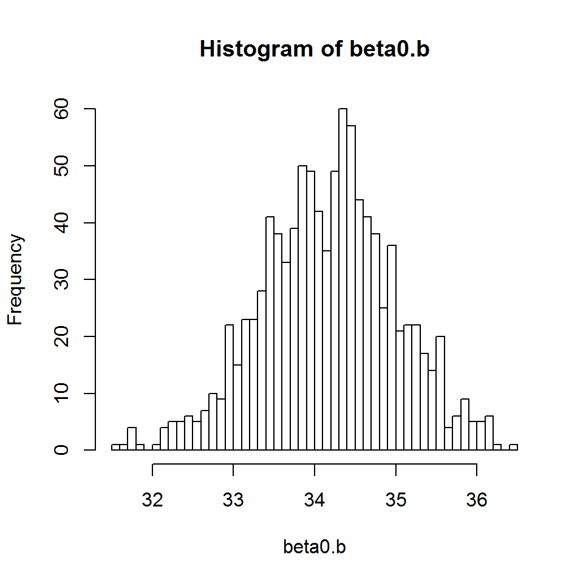

```r
hist(beta0.b,nclass=50)
```

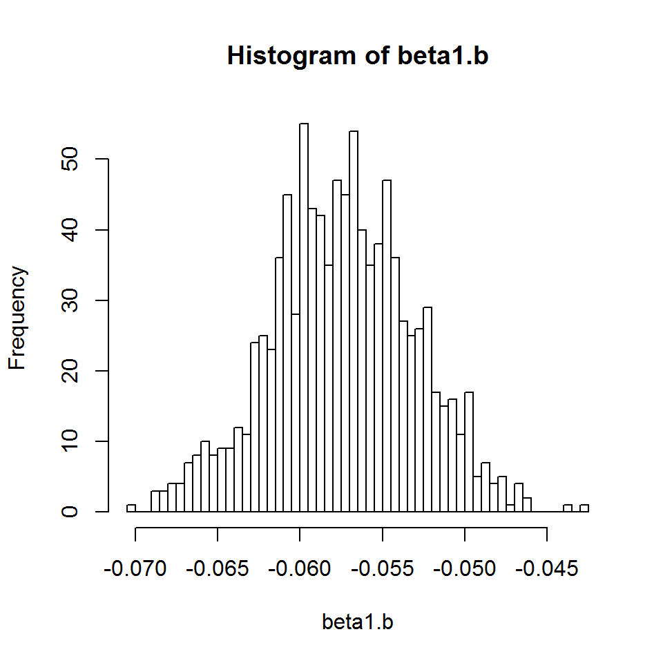

```r
hist(beta1.b,nclass=50)
```

$95\%$ C.Is for the intercept and slope.

```r
quantile(beta0.b,probs=c(0.025,0.975))
```

```
##     2.5%    97.5%
## 32.44776 35.81829
```

```r
quantile(beta1.b,probs=c(0.025,0.975))
```

```
##        2.5%       97.5%
## -0.06619278 -0.04928374
```

### 14.4.2 Semi-parametric bootstrap for the hormone data - inference

To implement the semi-parametric bootstrap procedure for inference, in the first step we the null model and calculate the residuals under the null, $e_{0,i}$ (the R object bellow).

```r
fit.lm<-lm(hormone$amount~hormone$hrs)
beta0<-summary(fit.lm)$coeff[1,1]
beta1<-summary(fit.lm)$coeff[2,1]
y<-hormone$amount
x<-hormone$hrs
fit.lm.0 <- lm(y ~ 1)
summary(fit.lm.0)
```

```
##
## Call:
## lm(formula = y ~ 1)
##
## Residuals:
##     Min      1Q  Median      3Q     Max
## -13.089  -3.939   1.111   5.361   8.111
##
## Coefficients:
##             Estimate Std. Error t value Pr(>|t|)
## (Intercept)   24.689      1.239   19.92   <2e-16 ***
## ---
## Signif. codes:  0 '***' 0.001 '**' 0.01 '*' 0.05 '.' 0.1 ' ' 1
##
## Residual standard error: 6.439 on 26 degrees of freedom
```

```r
ei.0 <- fit.lm.0$resid
```

The semi parametric bootstrap loop for inference ($H_{0}:\beta_{1}=0$) consists of following steps:

- Calculate the bootstrap replicates for the response $y^{*}_{1},\dots, y^{*}_{n}$ under the null  
  hypothesis in the following way

$$y^{*}_{i}=\hat{\beta}_{0}+e^{*}_{0,i}.$$

- Fit the model $y^{*}_{i}=\beta_{0}+\beta_{1} x_{i}+u_i$ and obtain the bootstrap replicates under $H_{0}$.

```r
n <- length(x)
B <- 1000
beta0.b <- beta1.b <- c(1:B)
for(i in 1:B) {
    e.boot <- sample(ei.0, size = n, replace = T)
    y.boot <- fit.lm.0$coeff[1] + e.boot
    x.boot <- x
    fit.boot <- lm(y.boot ~ x.boot)
    beta0.b[i] <- fit.boot$coeff[1]
    beta1.b[i] <- fit.boot$coeff[2]
}
```

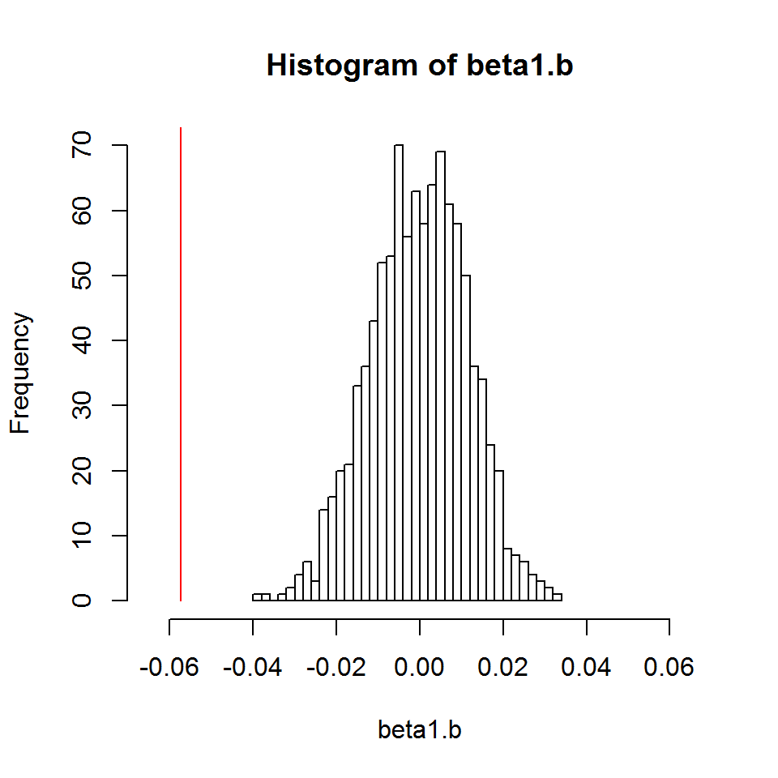

```r
hist(beta1.b,nclass=50,xlim=c(-0.065,0.065))
lines(c(beta1,beta1),c(0,1000),col=2)
```

## 14.5 Parametric bootstrap

For parametric bootstrap, we resample from an empirical distribution $F_{y_i}$ for which we make a an assumption about the parametric form, i.e., we assume that $y_{i}|x_{i}\sim N(\beta_{0}+\beta_{1}x_{i},\sigma^{2})$. Since we do not know $\beta_{0},\beta_{1}$ and $\sigma^{2}$ we replace them with their plug-in estimates. The parametric bootstrap algorithm can be implemented as follows.

- Fit the linear model
  $$y_{i}=\beta_{0}+\beta_{1} x_{i}+\varepsilon_i,$$
  and estimate the unknown parameters by $\hat{\beta}_{0}$, $\hat{\beta}_{1}$ and $\hat{\sigma}^{2}$.
- Start the bootstrap loop and for each $b = 1, \ldots, B$ resamples the response from the empirical distribution
  $$y^{*}_{i}|x_{i}\sim N(\hat{\beta}_{0}+\hat{\beta}_{1}x_{i},\hat{\sigma}^{2}).$$
- for B bootstrap samples we have

$$\begin{array}{ccc}
(y_1^*(1), x_{1}) & \ldots,&( y_n^*(1) ,x_{n}) \\
(y _1^*(2), x_{1})& \ldots,& (y _n^*(2) ,x_{n})\\
\vdots& & \\
(y _1^*(B), x_{1})& \ldots, &(y_n^* (B) ,x_{n})
\end{array}$$

- For each bootstrap sample fit the model

$$y^{*}_{i}=\beta_{0}+\beta_{1} x_{i}+u_i,$$

and obtained the bootstrap replicates $\hat{\beta}{*}_{0}$ and $\hat{\beta}{*}_{1}$

- Use the above bootstrap replicates for $\beta$ to estimate the standard error, confidence intervals, distribution etc.

### 14.5.1 Parametric bootstrap for the hormone data - estimation and C.Is

For parametrc bootstrap, we first fit the linear model and estimate the unknown parameters.

```r
fit.lm<-lm(hormone$amount~hormone$hrs)
beta0<-summary(fit.lm)$coeff[1,1]
beta1<-summary(fit.lm)$coeff[2,1]
sigma<-2.378
```

Within the bootstrap loop we resample from $N(\hat{\beta}_{0}+\hat{\beta}_{1}x_{i},\sigma^{2})$.

```r
B<-10000
beta0.b<-beta1.b<-c(1:B)
amount.b<-c(1:n)
for (i in 1:B)
{
for(j in 1:n)
{
amount.b[j]<-rnorm(1,beta0+beta1*hormone$hrs[j],sigma)
}
fit.lm.b<-lm(amount.b~hormone$hrs)
beta0.b[i]<-summary(fit.lm.b)$coeff[1,1]
beta1.b[i]<-summary(fit.lm.b)$coeff[2,1]
}
```

Distribution of the bootstrap replicates.

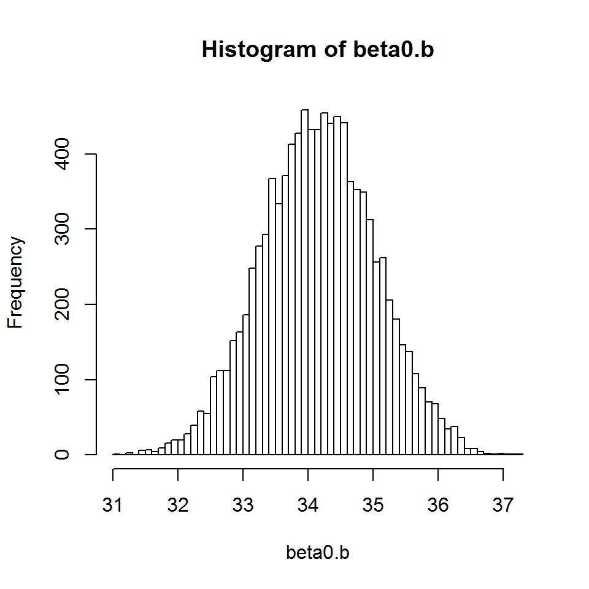

```r
hist(beta0.b,nclass=50)
```

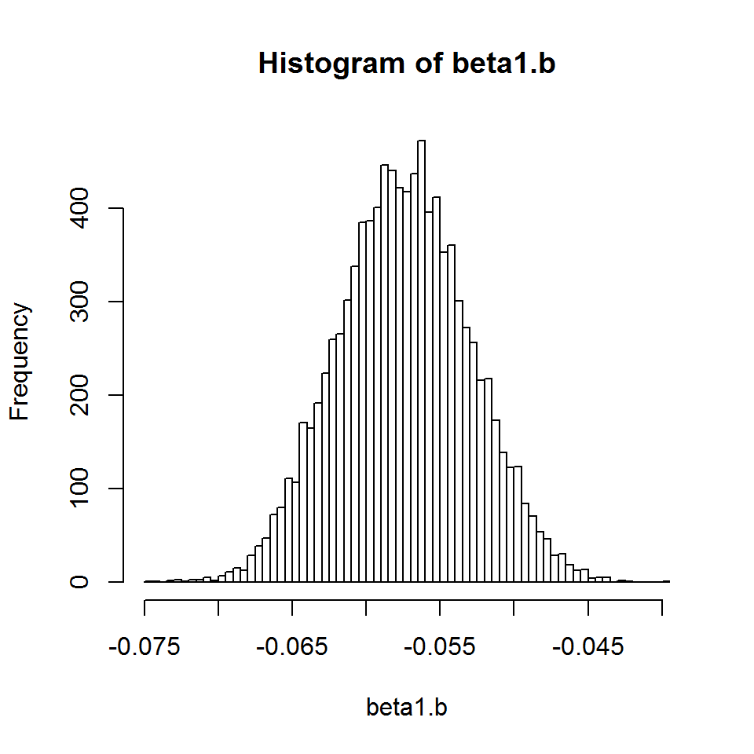

```r
hist(beta1.b,nclass=50)
```

$95\%$ C.Is for $\beta_{0}$ and $\beta_{1}$.

```r
quantile(beta0.b,probs=c(0.025,0.975))
```

```
##     2.5%    97.5%
## 32.47099 35.86872
```

```r
quantile(beta1.b,probs=c(0.025,0.975))
```

```
##        2.5%       97.5%
## -0.06601774 -0.04876212
```

### 14.5.2 Parametric bootstrap for the hormone data - inference

```r
fit.lm.0<-lm(hormone$amount~1)
summary(fit.lm.0)
```

```
##
## Call:
## lm(formula = hormone$amount ~ 1)
##
## Residuals:
##     Min      1Q  Median      3Q     Max
## -13.089  -3.939   1.111   5.361   8.111
##
## Coefficients:
##             Estimate Std. Error t value Pr(>|t|)
## (Intercept)   24.689      1.239   19.92   <2e-16 ***
## ---
## Signif. codes:  0 '***' 0.001 '**' 0.01 '*' 0.05 '.' 0.1 ' ' 1
##
## Residual standard error: 6.439 on 26 degrees of freedom
```

```r
beta0<-summary(fit.lm)$coeff[1,1]
beta1<-summary(fit.lm)$coeff[2,1]
sigma<-sqrt(6.439)
c(beta0,sigma)
```

```
## [1] 34.167528  2.537518
```

Within the parametric bootstrap loop we resample the bootstrap replicate $y^{*}_{i}$ from $N(\hat{\beta}_{0},\sigma^{2})$ using the function

```r
B<-10000
beta0.b<-beta1.b<-c(1:B)
amount.b<-c(1:n)
for (i in 1:B)
{
for(j in 1:n)
{
amount.b[j]<-rnorm(1,beta0,sigma)
}
fit.lm.b<-lm(amount.b~hormone$hrs)
beta0.b[i]<-summary(fit.lm.b)$coeff[1,1]
beta1.b[i]<-summary(fit.lm.b)$coeff[2,1]
}
```

The distribution of the bootstrap replicates under the null hypothesis.

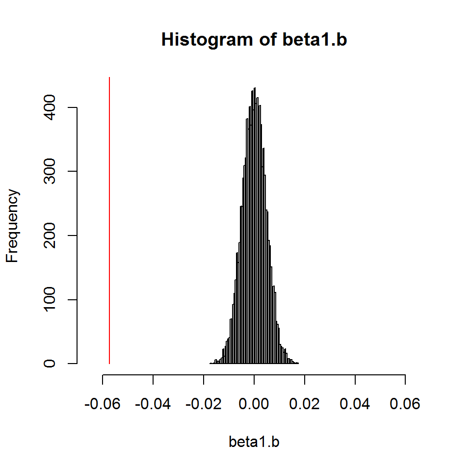

```r
hist(beta1.b,nclass=50,xlim=c(-0.065,0.065))
lines(c(beta1,beta1),c(0,1000),col=2)
```

## 14.6 Example: the cell survival data

Fourteen cell plates were exposed to different levels of radiation. The observed response was the proportion of cells which survived the radiation exposure. The response in plate 13 was considered somewhat uncertain by the investigator. Data are shown in the Figure and data.frame below.

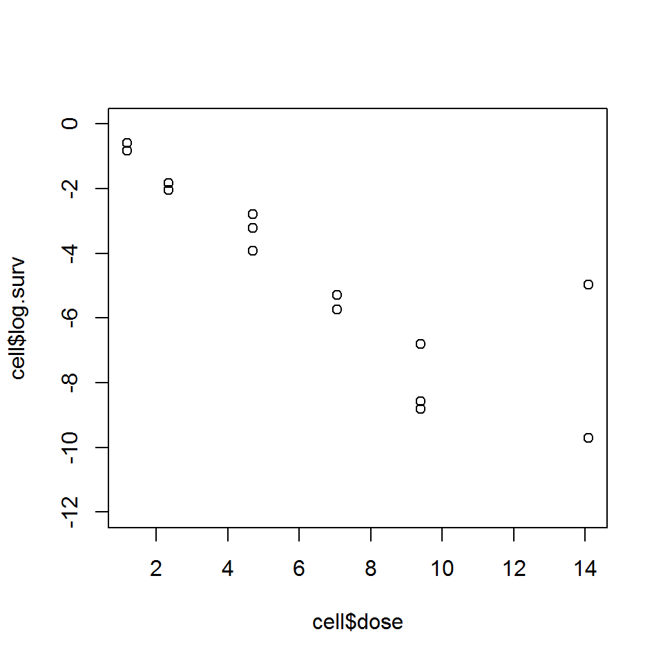

```r
library(bootstrap)
plot(cell$dose,cell$log.surv,ylim=c(-12,0))
```

```r
y<-cell$log.surv
x<-cell$dose
data.frame(x,y)
```

```
##         x      y
## 1   1.175 -0.821
## 2   1.175 -0.598
## 3   2.350 -1.833
## 4   2.350 -2.040
## 5   4.700 -3.219
## 6   4.700 -3.932
## 7   4.700 -2.794
## 8   7.050 -5.298
## 9   7.050 -5.745
## 10  9.400 -6.812
## 11  9.400 -8.805
## 12  9.400 -8.568
## 13 14.100 -4.962
## 14 14.100 -9.721
```

As mentioned above, there is uncertainty about the response for plate 13.

```r
c(x[13],y[13])
```

```
## [1] 14.100 -4.962
```

```r
x2<-x^2
x13<-x[-c(13)]
x132<-x13^2
y13<-y[-c(13)]
```

### 14.6.1 Quadratic models with and without observation 13 (n=13)

We fit two quadratic models with and without observation 13 included
$$Y_{i}=\beta_{1}x_{i}+\beta_{2}x^{2}_{i}+\varepsilon_i.$$

Note that both models are withut intercept.

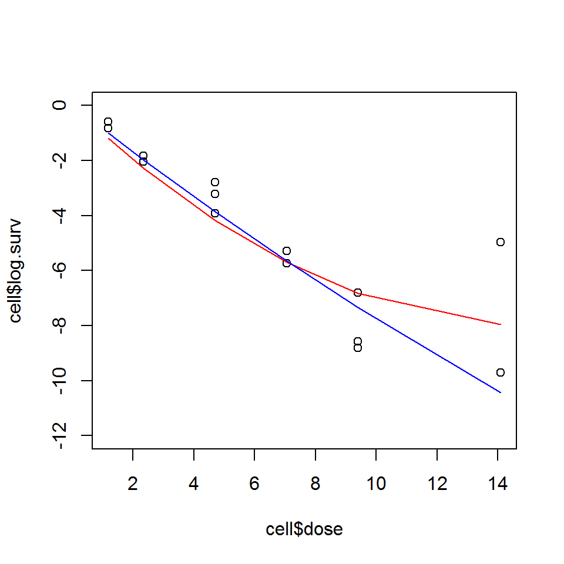

```r
plot(cell$dose,cell$log.surv,ylim=c(-12,0))
fit.lm2<-lm(y~-1+x+x2)
fit.lm2a<-lm(y13~-1+x13+x132)
#summary(fit.lm2)
#summary(fit.lm2a)
lines(x,fit.lm2$fit,col=2)
lines(x13,fit.lm2a$fit,col=4)
```

### 14.6.2 Models for all data (n=14)

For the complete data, a linear and quadratic models are fitted.
$$\begin{array}{l}
y_{i}=\beta_{1}x_{i}+\varepsilon_i, \\
y_{i}=\beta_{1}x_{i}+\beta_{2}x^{2}_{i}+\varepsilon_i.
\end{array}$$

Data and fitted models are sown below.

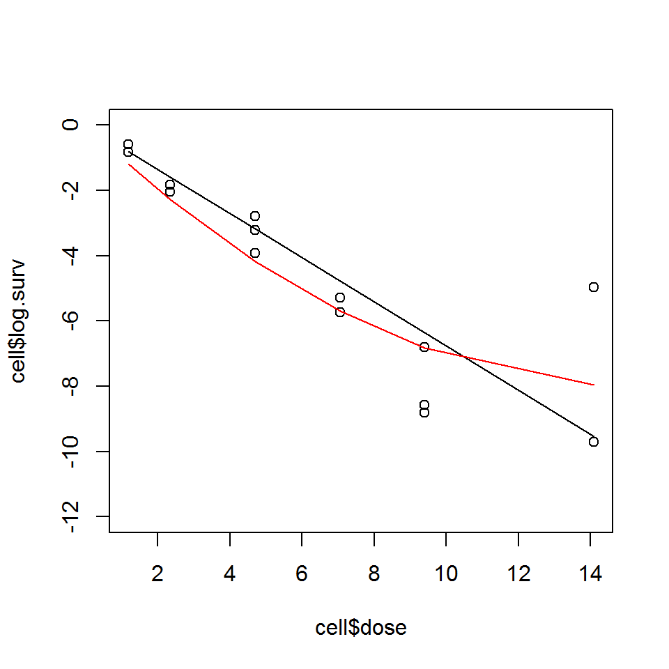

```r
plot(cell$dose,cell$log.surv,ylim=c(-12,0))
fit.lm1<-lm(y~-1+x)
fit.lm2<-lm(y~-1+x+x2)
#summary(fit.lm1)
#summary(fit.lm2)
lines(x,fit.lm1$fit)
lines(x,fit.lm2$fit,col=2)
```

### 14.6.3 Robust regression models for all data (n=14)

Three models are fitted to the complete data, a linear and quadratic regression models (estimated by OLS) and a robust regression model using the R package $rlm$. Data and fitted models are shown below.

```r
library(rlm)
library(MASS)
```

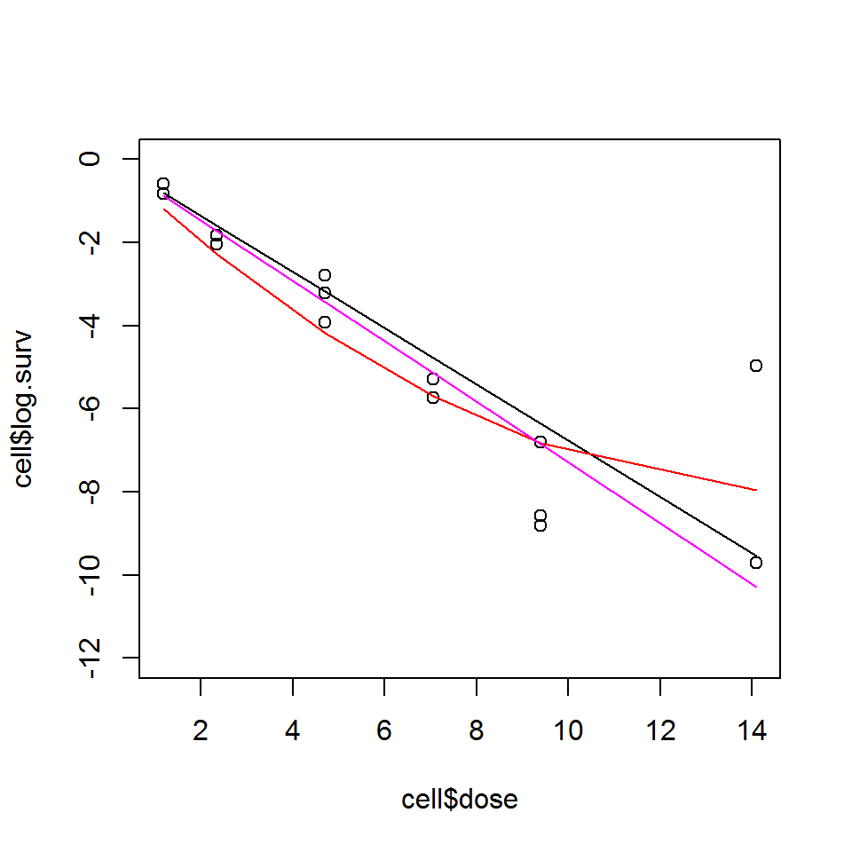

```r
plot(cell$dose,cell$log.surv,ylim=c(-12,0))
fit.lm1<-lm(y~-1+x)
fit.lm2<-lm(y~-1+x+x2)
lines(x,fit.lm1$fit)
lines(x,fit.lm2$fit,col=2)
fit.rob<-rlm(y~-1+x)
#summary(fit.rob)
lines(x,fit.rob$fit,col=6)
```

### 14.6.4 Calculating the residuals scores

We define the residual by

$$y_{i}-\hat{\beta}_{1}x_{i},$$

and we calculate three residuals scores: (1) the mean residuals sum of square, (2) the median residual and (3) the mean sum of absolute residuals. Our estimate $\beta$ by minimizing the score using a grid search over a sequence of $\beta$.

```r
beta<-seq(from=-0.9,to=-0.5,length=10000)
RAS<-RSS<-MSR<-c(1:10000)
n<-length(x)
for(i in 1:10000)
{
y.hat<-beta[i]*x
r<-(y-y.hat)
r.q<-r^2
RSS[i]<-(1/n)*sum(r.q)
MSR[i]<-median(r.q)
RAS[i]<-(1/n)*sum(abs(r))
}
m.RSS<-min(RSS)
m.MSR<-min(MSR)
m.RAS<-min(RAS)
beta.rss<-beta[RSS==m.RSS]
beta.msr<-beta[MSR==m.MSR]
beta.ras<-beta[RAS==m.RAS]
```

The OLS parameter estimate and the residual sum of squares score.

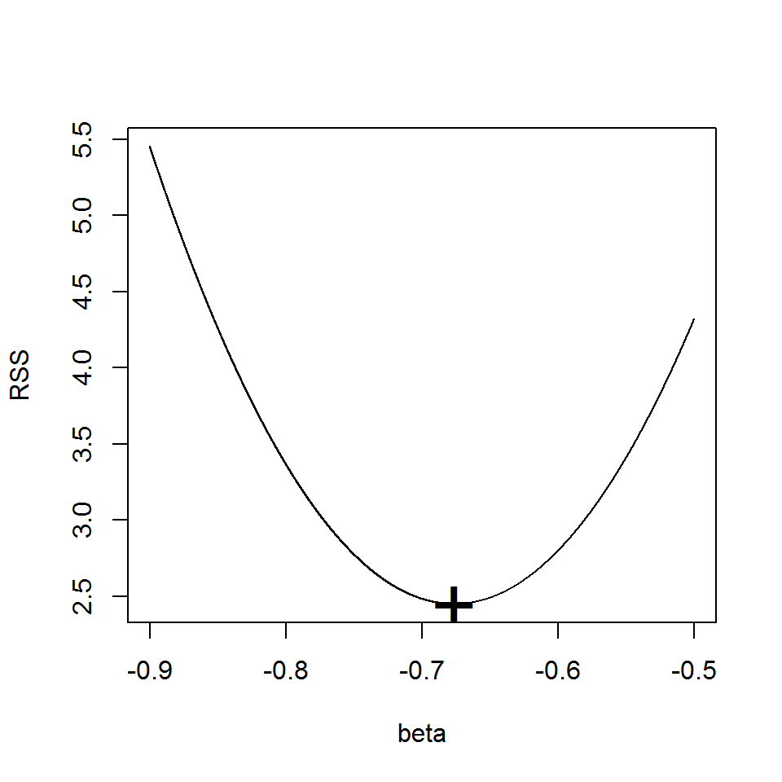

```r
plot(beta,RSS,type="l")
points(beta.rss,m.RSS,pch="+",cex=3)
```

```r
m.RSS
```

```
## [1] 2.449635
```

```r
beta.rss
```

```
## [1] -0.6764976
```

The median residual parameter estimate and the median residuals score.

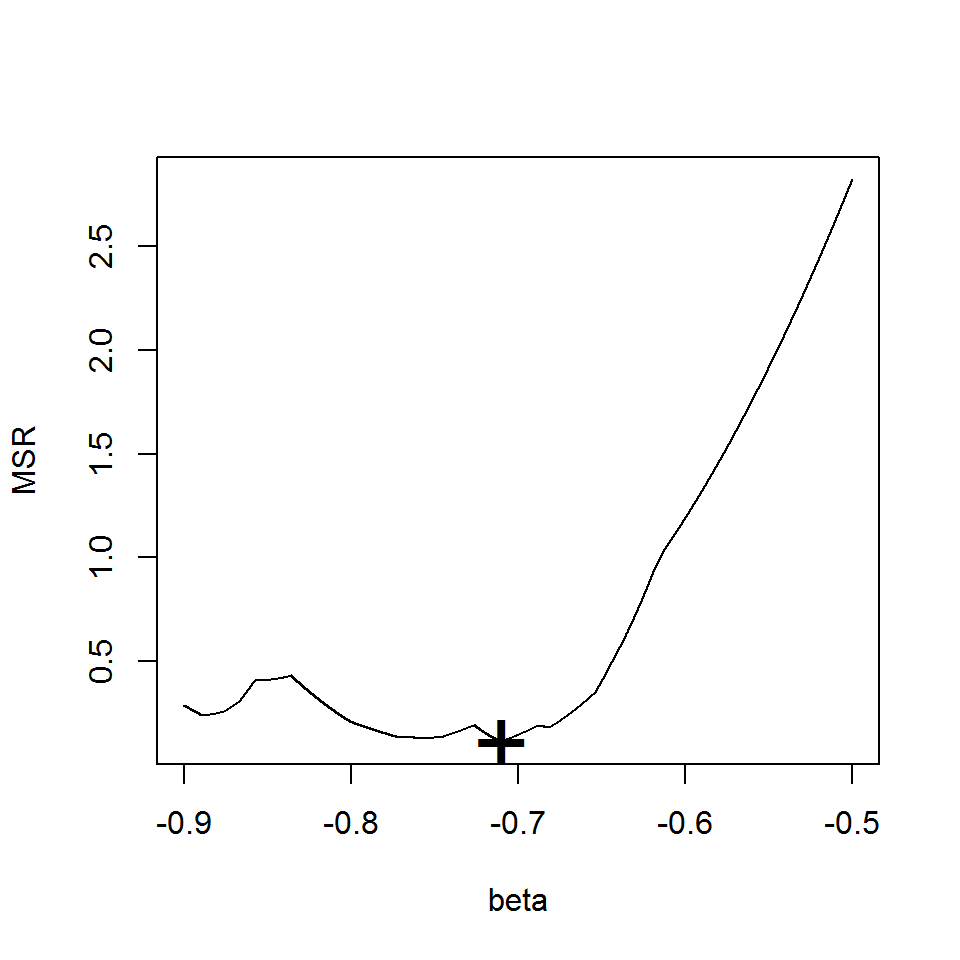

```r
plot(beta,MSR,type="l")
points(beta.msr,m.MSR,pch="+",cex=3)
```

```r
m.MSR
```

```
## [1] 0.1114881
```

```r
beta.msr
```

```
## [1] -0.710101
```

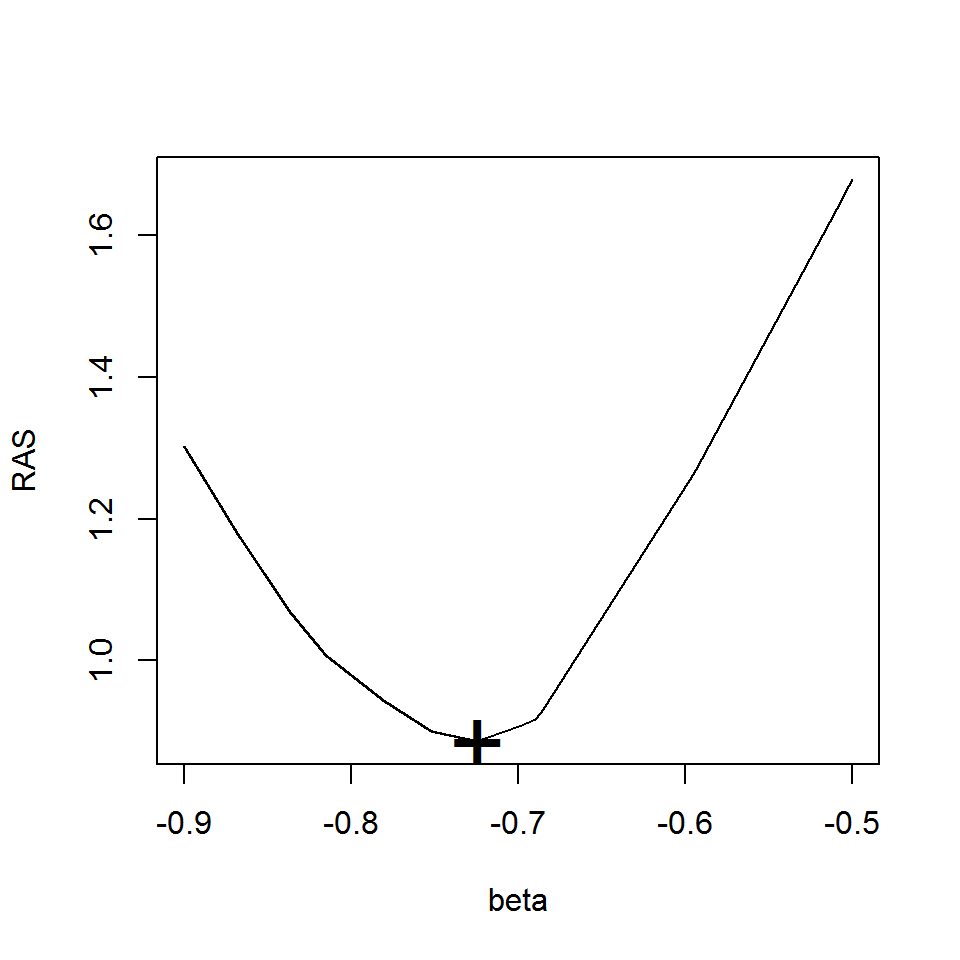

```r
plot(beta,RAS,type="l")
points(beta.ras,m.RAS,pch="+",cex=3)
```

```r
m.RAS
```

```
## [1] 0.8859395
```

```r
beta.ras
```

```
## [1] -0.7247025
```

Data and estimated models.

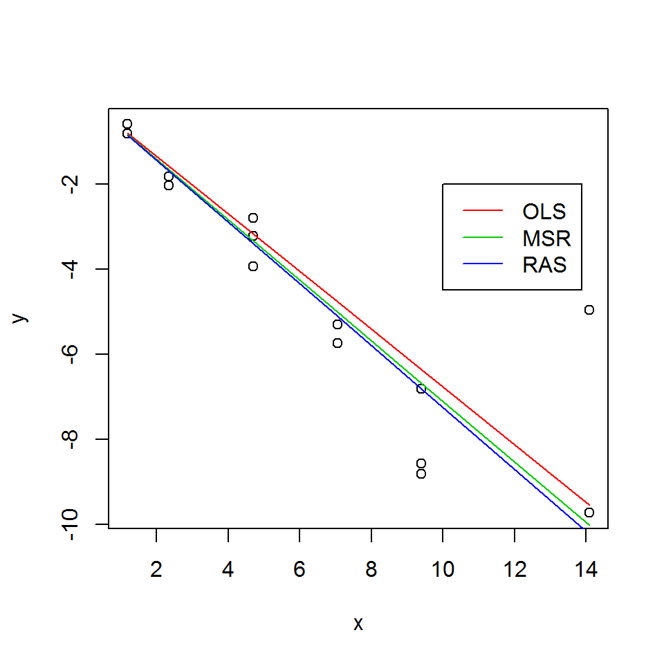

```r
plot(x,y)
lines(unique(x),unique(x)*beta.rss,col=2)
lines(unique(x),unique(x)*beta.msr,col=3)
lines(unique(x),unique(x)*beta.ras,col=4)
legend(10,-2,c("OLS","MSR","RAS"),lty=c(1,1,1),col=c(2,3,4))
```

Parameter estimates and residuals scores.

```r
mm<-c(m.RSS,m.MSR,m.RAS)
beta.i<-c(beta.rss,beta.msr,beta.ras)
data.frame(mm,beta.i)
```

```
##          mm     beta.i
## 1 2.4496353 -0.6764976
## 2 0.1114881 -0.7101010
## 3 0.8859395 -0.7247025
```

# 15 Generelized linear models

## 15.1 GLM: The setting

## 15.2 Example 1: dose-response models for binary data

### 15.2.1 The beetle data

```r
Dose<-c(1.6907,1.7242,1.7552,1.7842,1.8113,1.8369,1.8610,1.8839)
beetles<-c(59,60,62,56,63,59,62,60)
killed<-c(6,13,18,28,52,53,61,60)
beetle<-data.frame(Dose,beetles,killed)
beetle
```

```
##     Dose beetles killed
## 1 1.6907      59      6
## 2 1.7242      60     13
## 3 1.7552      62     18
## 4 1.7842      56     28
## 5 1.8113      63     52
## 6 1.8369      59     53
## 7 1.8610      62     61
## 8 1.8839      60     60
```

### 15.2.2 Logistic regression model for the beetle data

Let $y_{j}$ be the number of beetle died at does level $d_{j}$, $y_{j} \sim B(n_{j},\pi(d_{j}))$. We assume that the probability to die in the experiment is does dependent,

$$\pi(d_{j})=\frac{e^{\alpha+\beta d_j}}{1+e^{\alpha +\beta d_j}}.$$

For a logit link function

$$log \left ( \frac{\pi}{1-\pi} \right ),
\$$

the linear predictor is given by

$$\eta=\alpha+\beta d_j.$$

The above model is a logistic regression model, i.e., a GLM for binary data with a logit link function. In R, the model can be fitted using the function. Data and presented models are shown below.

```r
p.b<-killed/beetles
unkilled<-beetles-killed
Proportionkilled<-p.b
par(mfrow=c(1,1))
plot(Dose,Proportionkilled, main="Proportion of the killed beetles",ylim=c(0,1))
fit.beetles<-glm(cbind(killed,unkilled)~Dose,family=binomial(link = "logit"))
summary(fit.beetles)$coefficients
```

```
##              Estimate Std. Error   z value     Pr(>|z|)
## (Intercept) -60.71745   5.180701 -11.71993 1.007549e-31
## Dose         34.27033   2.912134  11.76811 5.698445e-32
```

```r
summary(fit.beetles)$coefficients[,3]
```

```
## (Intercept)        Dose
##   -11.71993    11.76811
```

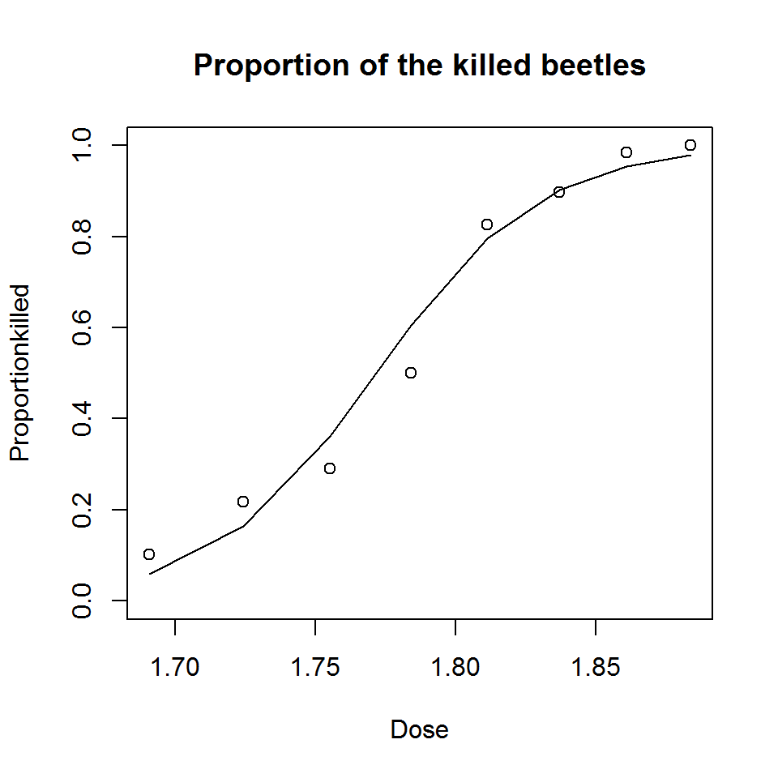

```r
lines(Dose,fit.beetles$fit)
```

### 15.2.3 Parametric bootstrap: estimation

A parametric bootstrap consists of resampling for $B(n_{j},\pi(d_{j}))$. Since the probability is unknown we use the sample proportions (the R object ).

```r
p.b<-beetle$killed/beetle$beetles
```

Note that then bootstrap procedure is implemented using a double for loop. In the inner loop we resample the bootstrap replicates ($y^{*}$) to create the bootstrap samples

$$y^{*}_{j} \ sim B(n_{j},\hat{\pi}(d_{j})),$$

for which the corresponding R code is given by . In the outer loop we resample $B$ bootstrap samples of $y^{*}$

```r
B<-1000
prob.boot<-matrix(0,8,B)
test.stat<-coeff.boot<-matrix(0,2,B)
pos.boot<-c(1:8)
for(b in 1:B)
{
for(i in 1:8)
{
pos.boot[i]<-sum(rbinom(beetles[i],1,p.b[i]))
}
neg.boot<-beetles-pos.boot
fit.boot<-glm(cbind(pos.boot,neg.boot)~Dose,family=binomial(link = "logit"))
prob.boot[,b]<-fit.boot$fit
coeff.boot[,b]<-fit.boot$coefficients
test.stat[,b]<-summary(fit.boot)$coefficients[,3]
}
```

The distribution of the bootstrap replicates of $\hat{\alpha}$ and $\hat{\beta}$ are shown below.

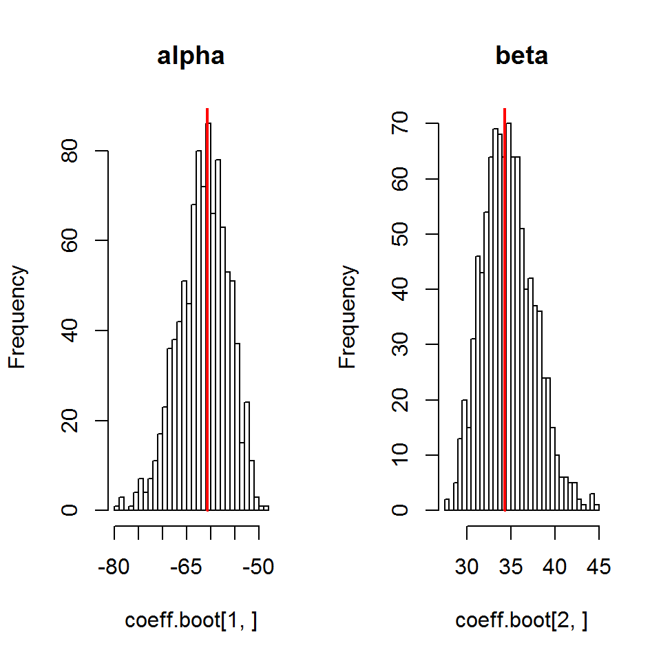

```r
par(mfrow=c(1,2))
hist(coeff.boot[1,],main="alpha",nclass=25)
lines(c(fit.beetles$coefficients[1],fit.beetles$coefficients[1]),c(0,550),
      col=2,lwd=2)
hist(coeff.boot[2,],main="beta",nclass=25)
lines(c(fit.beetles$coefficients[2],fit.beetles$coefficients[2]),c(0,300),
      col=2,lwd=2)
```

$95\%$ percentile intervals for $\alpha$ and $\beta$.

```r
quantile(coeff.boot[1,], probs = c(0.025, 0.975))
```

```
##      2.5%     97.5%
## -72.08468 -52.35010
```

```r
quantile(coeff.boot[2,], probs = c(0.025, 0.975))
```

```
##     2.5%    97.5%
## 29.56848 40.64445
```

We can construct a prediction interval for $\hat{\pi}(d_{j})$ using the bootstrap replicates for the prediction values (the R object ).

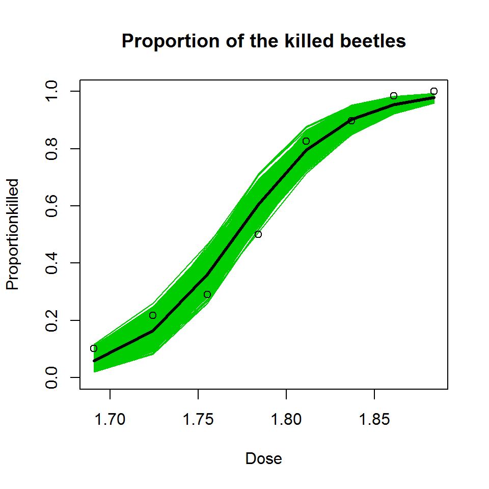

```r
par(mfrow=c(1,1))
plot(Dose,Proportionkilled, main="Proportion of the killed beetles",ylim=c(0,1))
lines(Dose,fit.beetles$fit)
for(b in 1:B)
{
lines(Dose,prob.boot[,b],col=3)
}
lines(Dose,fit.beetles$fit,col=1,lwd=3)
points(Dose,Proportionkilled)
```

## 15.3 Example: the malaria data

The malaria data gives information about the results of serological test for Malaria and consists of three variables, the age group of the subject, the number of seropositive () and the total number of subjects in each age group ().

```r
agei<-c(1.5,4.0,7.5,12.5,17.5,25.0,35.0,47.0,60)
posi<-c(8,6,18,14,20,39,19,25,44)
ntot<-c(123,132,182,140,138,161,133,92,74)
negi<-ntot-posi
cbind(agei,posi,negi)
```

```
##       agei posi negi
##  [1,]  1.5    8  115
##  [2,]  4.0    6  126
##  [3,]  7.5   18  164
##  [4,] 12.5   14  126
##  [5,] 17.5   20  118
##  [6,] 25.0   39  122
##  [7,] 35.0   19  114
##  [8,] 47.0   25   67
##  [9,] 60.0   44   30
```

### 15.3.1 Logistic regression for the malaria data

Our aim is to model the probability of infection which is assumed to be age dependent
$$\pi(a)=\frac{e^{\alpha+\beta \times age}}{1+e^{\alpha +\beta \times age}}.$$

For a model with a logit link function, the linear predictor is given by
$$\eta=\alpha+\beta \times age.$$

In R the model is fitted using the following code:

```r
fit.malaria1<-glm(cbind(posi,negi)~agei,family=binomial(link = "logit"))
summary(fit.malaria1)
```

```
##
## Call:
## glm(formula = cbind(posi, negi) ~ agei, family = binomial(link = "logit"))
##
## Deviance Residuals:
##      Min        1Q    Median        3Q       Max
## -2.78685  -1.31863  -0.05053   0.66752   2.38275
##
## Coefficients:
##              Estimate Std. Error z value Pr(>|z|)
## (Intercept) -2.714074   0.151740 -17.886   <2e-16 ***
## agei         0.044672   0.004511   9.904   <2e-16 ***
## ---
## Signif. codes:  0 '***' 0.001 '**' 0.01 '*' 0.05 '.' 0.1 ' ' 1
##
## (Dispersion parameter for binomial family taken to be 1)
##
##     Null deviance: 124.037  on 8  degrees of freedom
## Residual deviance:  21.865  on 7  degrees of freedom
## AIC: 66.388
##
## Number of Fisher Scoring iterations: 4
```

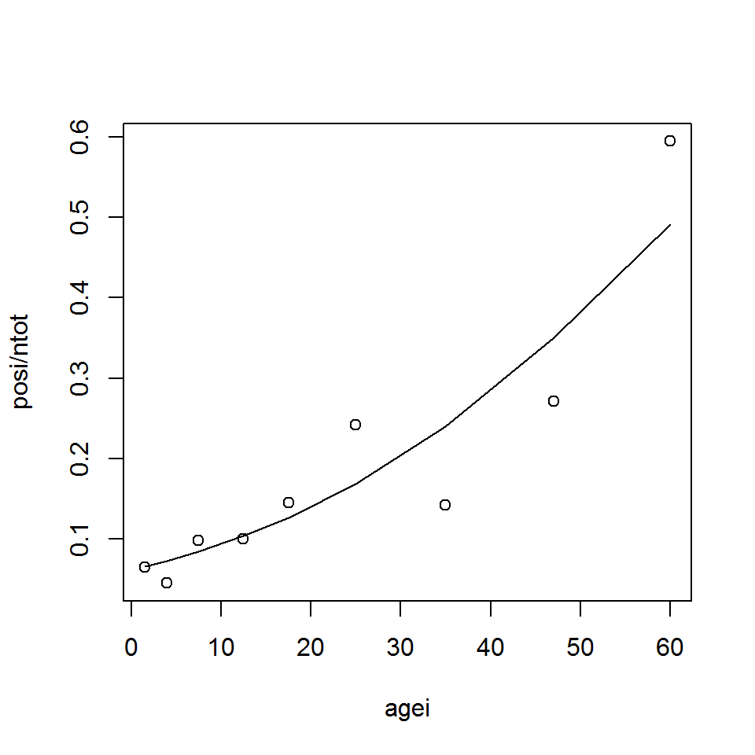

```r
plot(agei,posi/ntot)
lines(agei,fit.malaria1$fit)
```

### 15.3.2 Parametric bootstrap: estimation and C.Is

A parametric bootstrap for this example is similar to the procedure implement for the dose-response model in the previous chapter

```r
p.b<-posi/ntot
B<-1000
prob.boot<-matrix(0,9,B)
test.stat<-coeff.boot<-matrix(0,2,B)
pos.boot<-c(1:9)
for(b in 1:B)
{
for(i in 1:9)
{
pos.boot[i]<-sum(rbinom(ntot[i],1,p.b[i]))
}
neg.boot<-ntot-pos.boot
fit.boot<-glm(cbind(pos.boot,neg.boot)~agei,family=binomial(link = "logit"))
prob.boot[,b]<-fit.boot$fit
coeff.boot[,b]<-fit.boot$coefficients
test.stat[,b]<-summary(fit.boot)$coefficients[,3]
}
```

The distribution of the bootstrap replicates and $95\%$ C.Is are shown below.

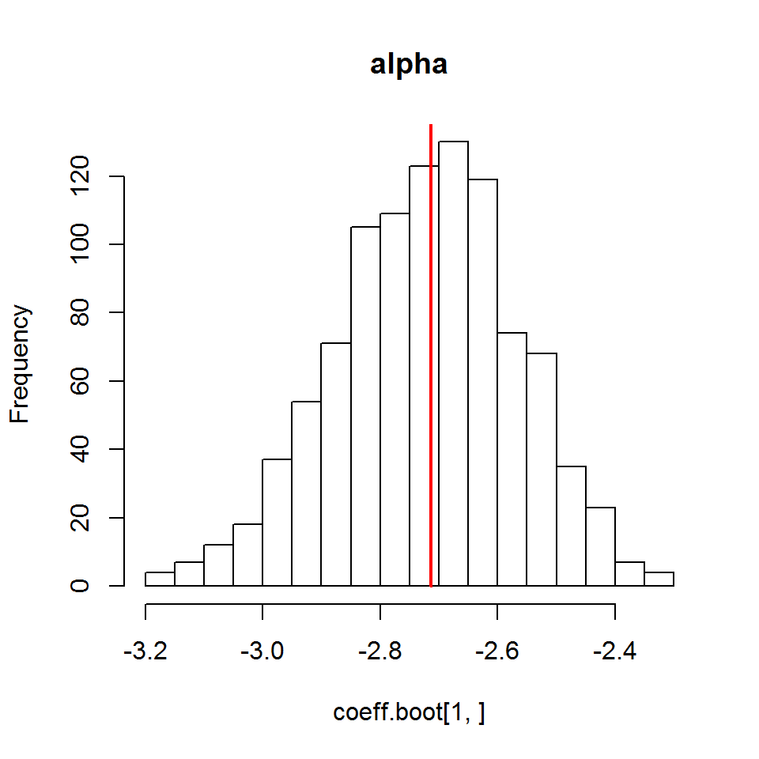

```r
par(mfrow=c(1,1))
hist(coeff.boot[1,],main="alpha",nclass=25)
lines(c(fit.malaria1$coefficients[1],fit.malaria1$coefficients[1]),c(0,550),
      col=2,lwd=2)
```

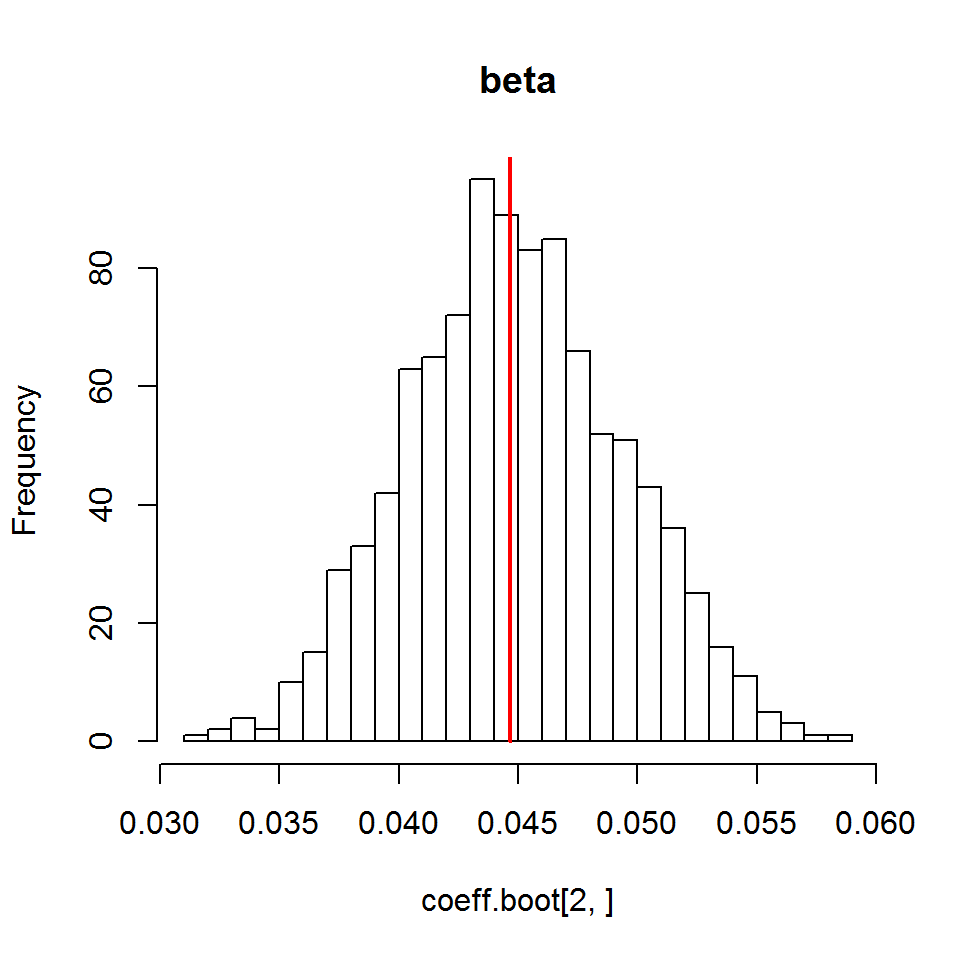

```r
hist(coeff.boot[2,],main="beta",nclass=25)
lines(c(fit.malaria1$coefficients[2],fit.malaria1$coefficients[2]),c(0,300),
      col=2,lwd=2)
```

```r
quantile(coeff.boot[1,], probs = c(0.025, 0.975))
```

```
##      2.5%     97.5%
## -3.044648 -2.437350
```

```r
quantile(coeff.boot[2,], probs = c(0.025, 0.975))
```

```
##       2.5%      97.5%
## 0.03643347 0.05345536
```

Bootstrap confidence intervals for the predicted values.

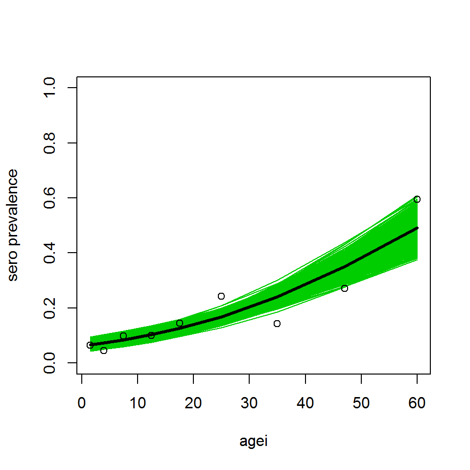

```r
par(mfrow=c(1,1))
plot(agei,p.b, ylab="sero prevalence",ylim=c(0,1))
lines(agei,fit.malaria1$fit)
for(b in 1:B)
{
lines(agei,prob.boot[,b],col=3)
}
lines(agei,fit.malaria1$fit,col=1,lwd=3)
points(agei,p.b)
```

### 15.3.3 Parametric bootstrap: inference

Suppose that we would like to test the hypothesis that age has not effect of the probability of infection. That is
$$H_{0}:\beta=0.$$
The null model (of no age effect) can be fitted using the following code

```r
fit.malaria0<-glm(cbind(posi,negi)~1,family=binomial(link = "logit"))
summary(fit.malaria0)$coefficients
```

```
##              Estimate Std. Error   z value     Pr(>|z|)
## (Intercept) -1.626901 0.07873747 -20.66235 7.559447e-95
```

The probability of infection inder $H_{0}$ is equal at each dose level

```r
eta<- -1.62690
prob.i<-exp(eta)/(1+exp(eta))
prob.i<-rep(prob.i,9)
prob.i
```

```
## [1] 0.1642555 0.1642555 0.1642555 0.1642555 0.1642555 0.1642555 0.1642555 0.1642555 0.1642555
```

and equal to the overall proportion of infection as can be seen on the figure below.

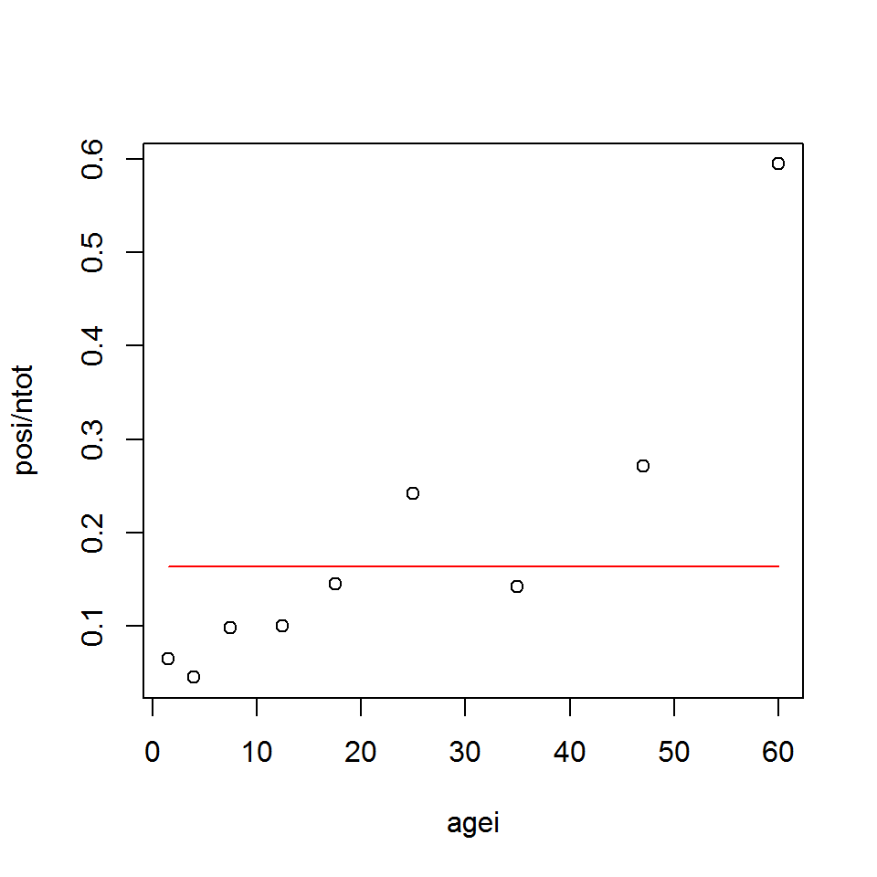

```r
plot(agei,posi/ntot)
lines(agei,prob.i,col=2)
```

The parametric bootstrap consists of resampling from a binomial distribution under $H_{0}$,

$$y^{*}_{j} \sim B(n_{j},\pi_{H_{0}}).$$

With $\pi_{H_{0}}=$ .

```r
B<-1000
prob.boot<-matrix(0,9,B)
test.stat<-coeff.boot<-matrix(0,2,B)
pos.boot<-c(1:9)
for(b in 1:B)
{
for(i in 1:9)
{
pos.boot[i]<-sum(rbinom(ntot[i],1,prob.i[i]))
}
neg.boot<-ntot-pos.boot
fit.boot<-glm(cbind(pos.boot,neg.boot)~agei,family=binomial(link = "logit"))
prob.boot[,b]<-fit.boot$fit
coeff.boot[,b]<-fit.boot$coefficients
test.stat[,b]<-summary(fit.boot)$coefficients[,3]
}
```

The distributions of bootstrap replicates for $\hat{\beta}^{*}_{b}$ and the teststatistic $t^{*}_{\beta,b}$ with the observed values are shown below. The monte carlo p value, in both cases, is equal to $\frac{1}{B+1}$.

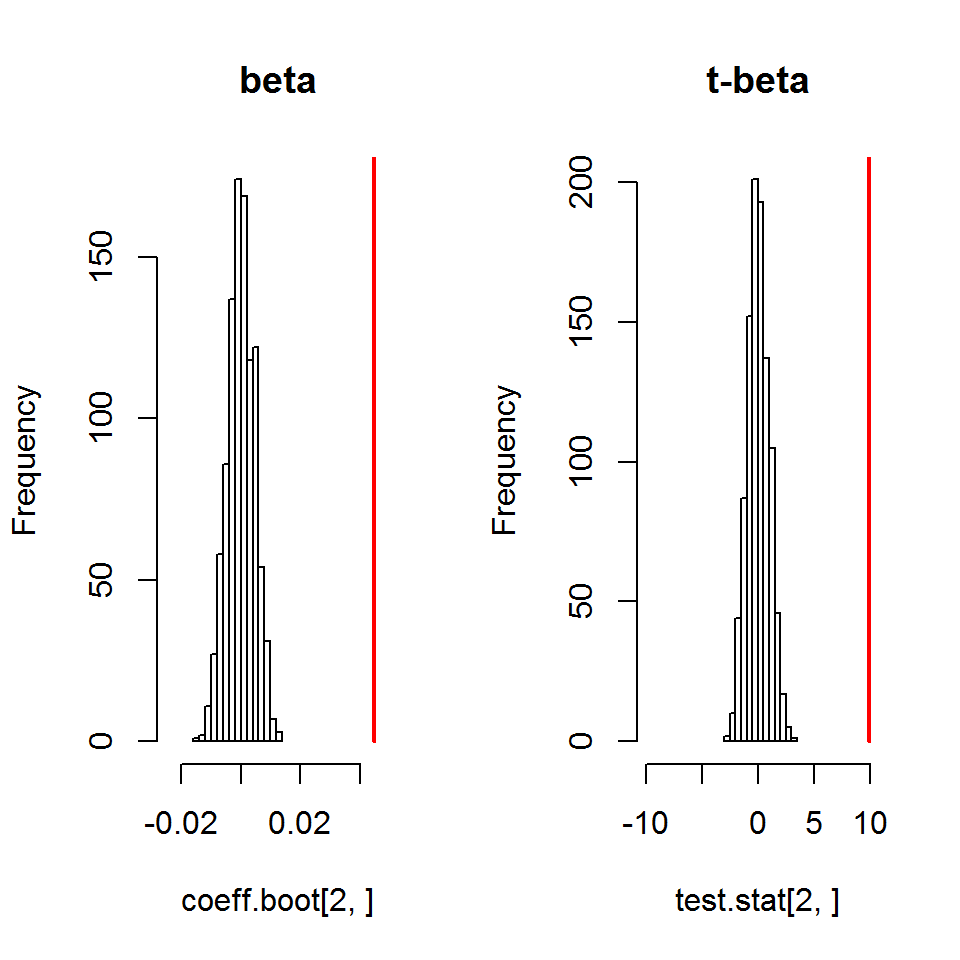

```r
par(mfrow=c(1,2))
hist(coeff.boot[2,],main="beta",xlim=c(-0.025,0.05))
lines(c(fit.malaria1$coefficients[2],fit.malaria1$coefficients[2]),c(0,300),
      col=2,lwd=2)
hist(test.stat[2,],main="t-beta",xlim=c(-10,10))
lines(c(9.903614,9.903614),c(0,300),
      col=2,lwd=2)
```

## 15.4 Example: the stress data

### 15.4.1 The data

```r
month<-c(1:18)
respondents<-c(15,11,14,17,5,11,10,4,8,10,7,9,11,3,6,1,1,4)
stress<-data.frame(month,respondents)
stress
```

```
##    month respondents
## 1      1          15
## 2      2          11
## 3      3          14
## 4      4          17
## 5      5           5
## 6      6          11
## 7      7          10
## 8      8           4
## 9      9           8
## 10    10          10
## 11    11           7
## 12    12           9
## 13    13          11
## 14    14           3
## 15    15           6
## 16    16           1
## 17    17           1
## 18    18           4
```

### 15.4.2 Poisson regression for the stress data

Let $y_{i}$ be the number of respondents that experienced at least one event in the $i$th month. Since this is a count data we assume

$$y_{i} \sim Poisson (\mu_{i}).$$

Here, $\mu_{i}$ is the mean number of respondents at the $i$th month. We assume a model with log link function with linear predictor given by

$$log(\mu_{i})=\alpha+\beta \times x_{i}.$$

The above model can be fitted in R using the function with the argument . Data and predicted model are shown below.

```r
respGLM <- glm(respondents ~ month, family=poisson, data=stress)
summary(respGLM)
```

```
##
## Call:
## glm(formula = respondents ~ month, family = poisson, data = stress)
##
## Deviance Residuals:
##     Min       1Q   Median       3Q      Max
## -1.9886  -0.9631   0.1737   0.5131   2.0362
##
## Coefficients:
##             Estimate Std. Error z value Pr(>|z|)
## (Intercept)  2.80316    0.14816  18.920  < 2e-16 ***
## month       -0.08377    0.01680  -4.986 6.15e-07 ***
## ---
## Signif. codes:  0 '***' 0.001 '**' 0.01 '*' 0.05 '.' 0.1 ' ' 1
##
## (Dispersion parameter for poisson family taken to be 1)
##
##     Null deviance: 50.843  on 17  degrees of freedom
## Residual deviance: 24.570  on 16  degrees of freedom
## AIC: 95.825
##
## Number of Fisher Scoring iterations: 5
```

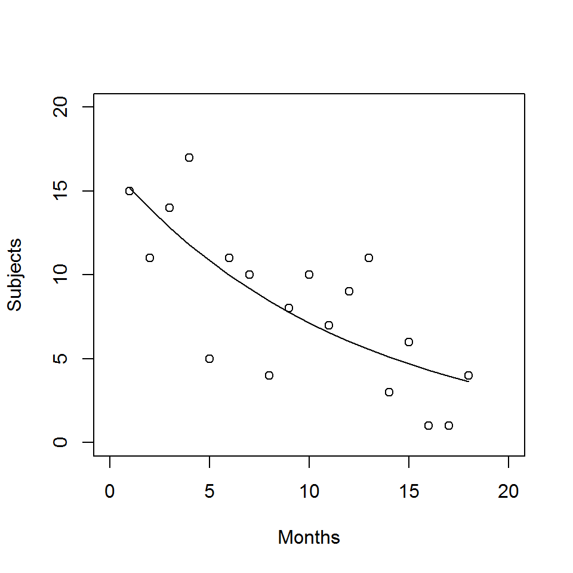

```r
plot(respondents ~ month, xlab = "Months",ylab = "Subjects", xlim=c(0,20), ylim=c(0,20))
lines(month,respGLM$fit)
```

### 15.4.3 Non parametric bootstrap: Estimation and C.Is

A non parametric procedure with the aim to construct C.Is requires to resample pairs. In the code below this is done using an index vector. Note that at each bootstrap iteration, the bootstrap sample is

```r
n<-length(stress[,1])
index<-c(1:n)
B<-10000
beta0.b<-beta1.b<-c(1:B)
for (i in 1:B)
{
index.b<-sample(index,n,replace=TRUE)
stress.b<-stress[index.b,]
fit.glm.b<-glm(stress.b$respondents ~ stress.b$month, family=poisson)
beta0.b[i]<-summary(fit.glm.b)$coeff[1,1]
beta1.b[i]<-summary(fit.glm.b)$coeff[2,1]
}
```

Distribution of the bootstrap replicates and $95\%$ C.Is for the parameters are given below.

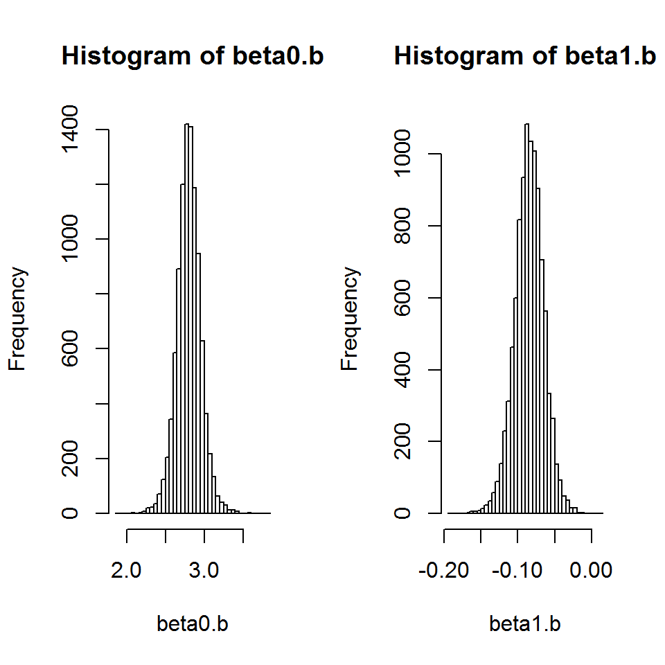

```r
par(mfrow=c(1,2))
hist(beta0.b,nclass=50)
hist(beta1.b,nclass=50)
```

```r
quantile(beta0.b,probs=c(0.025,0.975))
```

```
##     2.5%    97.5%
## 2.485106 3.115890
```

```r
quantile(beta1.b,probs=c(0.025,0.975))
```

```
##        2.5%       97.5%
## -0.12457665 -0.04635552
```

### 15.4.4 Non parametric bootstrap: inference

In this section we would like to test the null hypothesis
$$H_{0}:\beta=0.$$

For a non parametric bootstrap, this implies that we need to resample under the null hypothesis, i.e. we need to resample the month and the respondents separately.

```r
attach(stress)
n<-length(stress[,1])
B<-10000
beta0.b<-beta1.b<-c(1:B)
for (i in 1:B)
{
#stress.b<-stress[index.b,]
respondents.b<-sample(respondents, size=n, replace = TRUE)
month.b<-sample(month,size=n, replace = TRUE)
fit.glm.b<-glm(respondents.b ~ month.b, family=poisson)
beta0.b[i]<-summary(fit.glm.b)$coeff[1,1]
beta1.b[i]<-summary(fit.glm.b)$coeff[2,1]
}
```

As a test statistic we use $\hat{\beta}$. The observed slope is

```r
respGLM <- glm(respondents ~ month, family=poisson, data=stress)
beta1.obs<-summary(respGLM)$coeff[2,1]
```

Distribution of the test statistic under the null is shown below

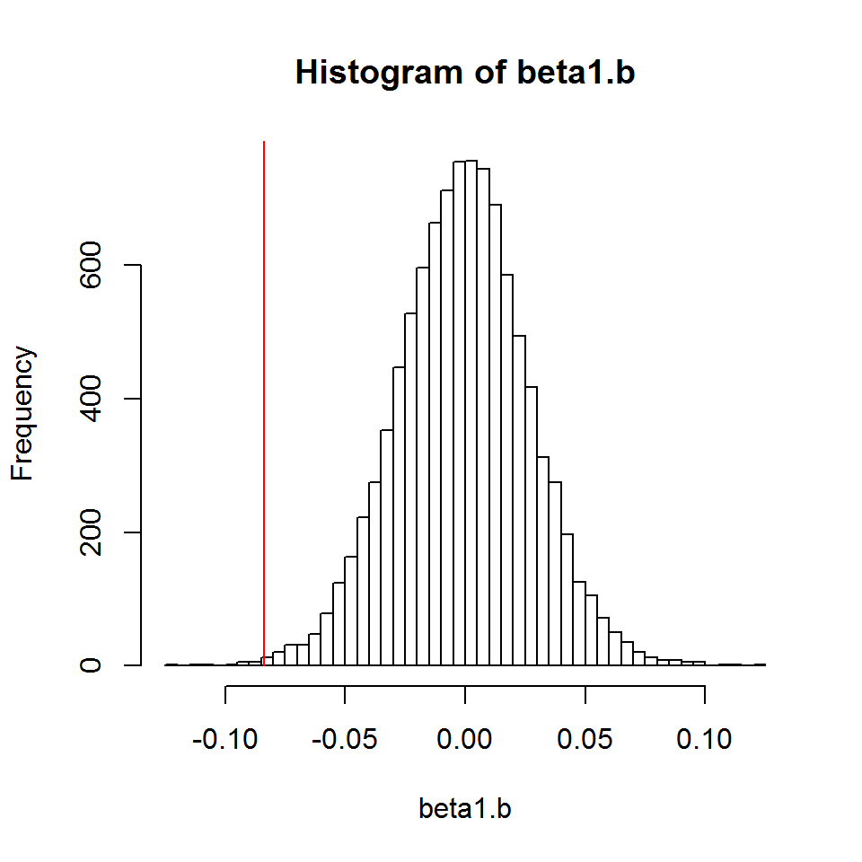

```r
par(mfrow=c(1,1))
hist(beta1.b,nclass=50)
lines(c(beta1.obs,beta1.obs),c(0,1000),col=2)
```

Monte carlo p value.

```r
(1+sum(abs(beta1.b)>abs(beta1.obs)))/(B+1)
```

```
## [1] 0.00439956
```

### 15.4.5 Parametric bootstrap: inference

For a parametric bootstrap, we need to resample the bootstrap replicates for $y$ from a Poisson distribution taking the null hypothesis into account,

$$y_{i} \sim Poisson (\mu_{H_{0},i}).$$

For an estimate for the mean under the null we use the sample mean $\hat{\mu}=\bar{x}$.

```r
hat.mu<-mean(respondents)
hat.mu
```

```
## [1] 8.166667
```

At each bootstrap iteration, we use the function to resample the bootstrap replicates. Note that we fixed the values of the months.

```r
n<-length(stress[,1])
B<-10000
beta0.b<-beta1.b<-c(1:B)
for (i in 1:B)
{
respondents.b<-rpois(n,hat.mu)
month.b<-month
fit.glm.b<-glm(respondents.b ~ month.b, family=poisson)
beta0.b[i]<-summary(fit.glm.b)$coeff[1,1]
beta1.b[i]<-summary(fit.glm.b)$coeff[2,1]
}
```

Distribution of the test statistic under the null and monte carlo p values are shown below

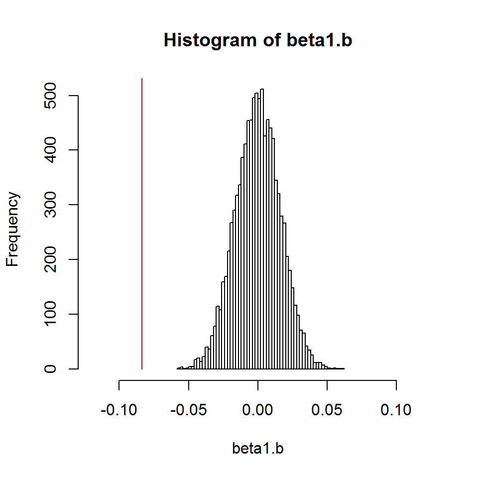

```r
par(mfrow=c(1,1))
hist(beta1.b,nclass=50,xlim=c(-0.12,0.12))
lines(c(beta1.obs,beta1.obs),c(0,1000),col=2)
```

```r
(1+sum(abs(beta1.b)>abs(beta1.obs)))/(B+1)
```

```
## [1] 9.999e-05
```

# 16 Estimation of bias

In this chapter we focus on the bias of the plug-in estimate. Let $F(\theta)$ be an unknown probability distribution, $\theta$ be the parameter of primary interest, $\theta=t(F)$ and let $\hat{\theta}$ the plug-in estimate. The (asymptotic) bias is given by
$$E(\hat{\theta}) - \theta.$$
For example, if $\theta$ is the mean of $F$ and $\hat{theta}=\bar{x}$ is the sample mean we can show that the sample mean is an unbiased estimate for the mean snice $E(\hat{\theta}=E(\bar{x})=\theta$. In the chapter we discuss the application of the bootstrap to calculate the bias of any parameter estimate of interest.

## 16.1 Estimating the bias using bootstrap

Let us assume that $x_{1}\dots,x_{n}$ is a random sample from $F(\theta)$ and that a bootstrap procedure (parametric or non parametric) was applied to the data. Let
$$\hat{\theta}^{*}_{1},\dots, \hat{\theta}^{*}_{B},$$
be the bootstrap replicates. For any parameter estimate of interest, the bootstrap estimate for $E(\hat{\theta})$ is the mean of the bootstrap replicates given by

$$\bar{\hat{\theta}}^{*}=\frac{1}{B}\sum_{b=1}^{B} \hat{\theta}^{*}_{b}.$$

The bootstrap estimates for the bias is defined as:

$$\bar{\hat{\theta}}^{*}-\hat{\theta}.$$

## 16.2 Example: the patch data

The patch data consists of 8t subjects used medical patches design to decrease the level of a certain hormone in the blood. Each subject was measured three times, at baseline (using a placebo patch), using old patch and using new patch. Data is shown below.

```r
library(bootstrap)
patch
```

```
##   subject placebo oldpatch newpatch     z     y
## 1       1    9243    17649    16449  8406 -1200
## 2       2    9671    12013    14614  2342  2601
## 3       3   11792    19979    17274  8187 -2705
## 4       4   13357    21816    23798  8459  1982
## 5       5    9055    13850    12560  4795 -1290
## 6       6    6290     9806    10157  3516   351
## 7       7   12412    17208    16570  4796  -638
## 8       8   18806    29044    26325 10238 -2719
```

The parameter estimate is the sample ratio

```r
y<-patch$y
z<-patch$z
mean(y)
```

```
## [1] -452.25
```

```r
mean(z)
```

```
## [1] 6342.375
```

The observed ratio:

```r
theta.obs<-mean(y)/mean(z)
theta.obs
```

```
## [1] -0.0713061
```

Our main interest is to estimate the bias of the ratio. A non parametric bootstrap for the ratio:

```r
n<-length(z)
B<-1000
index<-c(1:n)
theta.boot<-c(1:B)
for(i in 1:B)
{
i.boot<-sample(index, size=n, replace=T)
y.boot<-y[i.boot]
z.boot<-z[i.boot]
theta.boot[i]<-mean(y.boot)/mean(z.boot)
}
```

Distribution of the bootstrap replicates and the observed ratio.

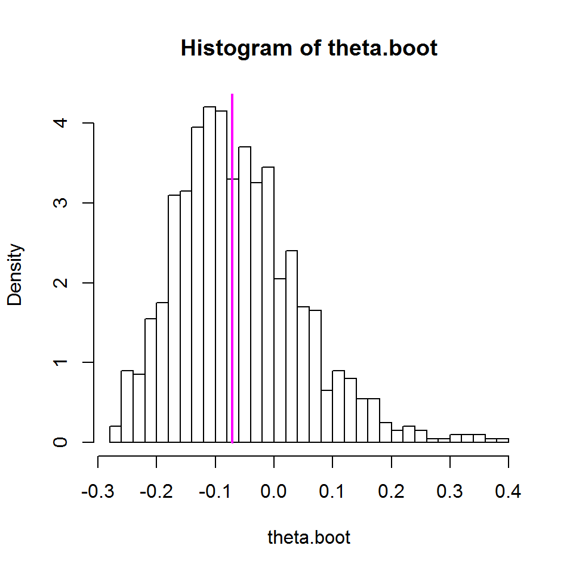

```r
hist(theta.boot,col=0,nclass=30,probability=T)
lines(c(theta.obs,theta.obs),c(0,5),lwd=2,col=6)
```

Calculating the bias.

```r
m.boot <- mean(theta.boot)
b.boot <- m.boot - theta.obs
b.boot
```

```
## [1] 0.01183352
```

Visualizing the bias and the bootstrap replicates.

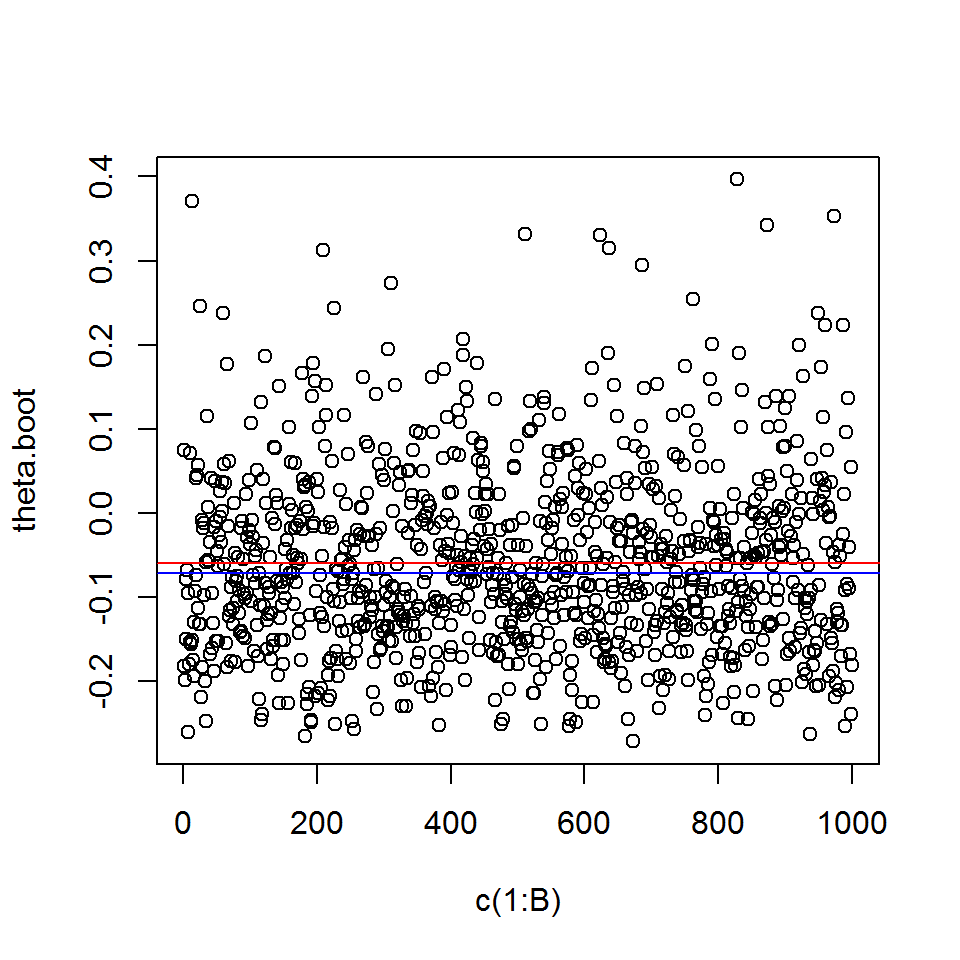

```r
plot(c(1:B),theta.boot)
abline(m.boot,0,col=2)
abline(theta.obs,0,col=4)
```

Zoom in to the bias and the bootstrap replicates.

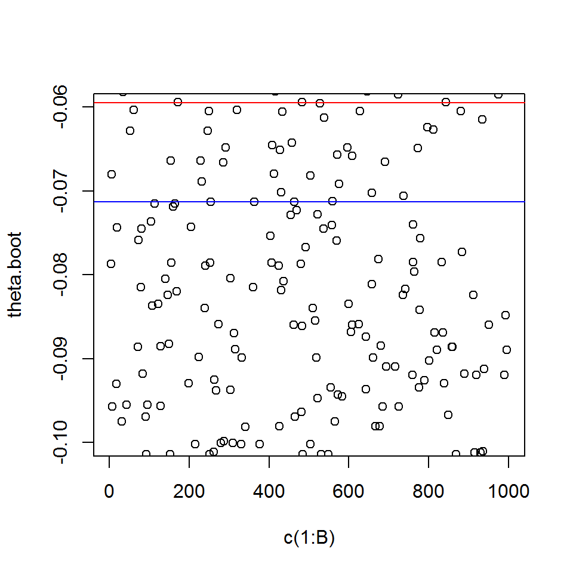

```r
plot(c(1:B),theta.boot,ylim=c(-0.1,-0.06))
abline(m.boot,0,col=2)
abline(theta.obs,0,col=4)
```

# 17 The jackknife

## 17.1 The jackkinfe procedure

Jackknife is a resampling procedure that can be used to calculate the standard error or bias of an estimate. In each resampling step of the jackknife loop, one observation from the original sample is left out. Let $(x_{1} \dots, x_{i-1}, x_{i}, x_{i+1}x_{n})$ be a random sample from the unknown probability distribution $F(\theta)$. Our aim is to estimate the unknown parameter(s) $\theta$ and it standard error and possible bias. The jackknife sample consists of leaving out one observation from the observed sample. The $i$th jackknife sample, consists of $n-1$ observations, is given by

$$(x_{1} \dots, x_{i-1}, x_{i+1}x_{n}).$$

Let us assume that $\theta$ is the mean $F(\theta)$. Let $\hat{\theta}^{(-i)}$ be the mean of the $i$th jackknife sample given by
$$\hat{\theta}^{(-i)}=\frac{1}{n-1}\sum_{j,j\ne i}x_{j}.$$

The jackknife estimate for the mean is equal to
$$\hat{\theta}^{(.)}=\frac{1}{n}\sum_{i}\hat{\theta}^{(-i)}.$$

The jackknife standard error for $\hat{\theta}$ is given by
$$SE\hat{\theta}=\frac{n-1}{n}\sum_{i=1}^{n} \left ( \hat{\theta}^{(-i)}- \hat{\theta}^{(.)} \right )^{2}.$$
The term $(n-1)$ is called the inflation factor. The inflation factor is needed since the jackknife replicates have less variability around the mean due to the fact that at each iteration only one observation is taken out the observed sample. Therefore, if we do not use the inflation factor we will under estimate the variability of the parameter estimate. This point will be illustrated in the flowing sections.

The jackknife estimate for the bias:
$$(n-1) \left ( \hat{\theta}^{(.)}- \hat{\theta} \right ).$$

## 17.2 Example: the airquality data

The airquality data gives information about the daily air quality in New York, May to September 1973. In this section we focus on the mean Ozone in parts per billion from 1300 to 1500 hours at Roosevelt Island. The parameter of primary interest is the mean ozone level.

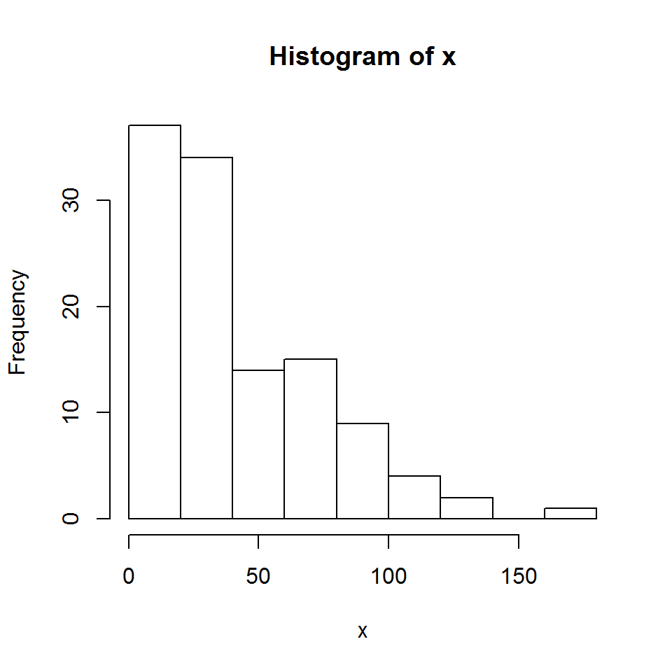

```r
x <- na.omit(airquality$Ozone)
hist(x, col = 0)
```

```r
mean(x)
```

```
## [1] 42.12931
```

```r
n <- length(x)
n
```

```
## [1] 116
```

```r
var(x)/n
```

```
## [1] 9.381039
```

We apply both non parametric bootstrap and jackknife procedures to the data. A Non parametric bootstrap procedure for the airquality data can be implemented using the code:

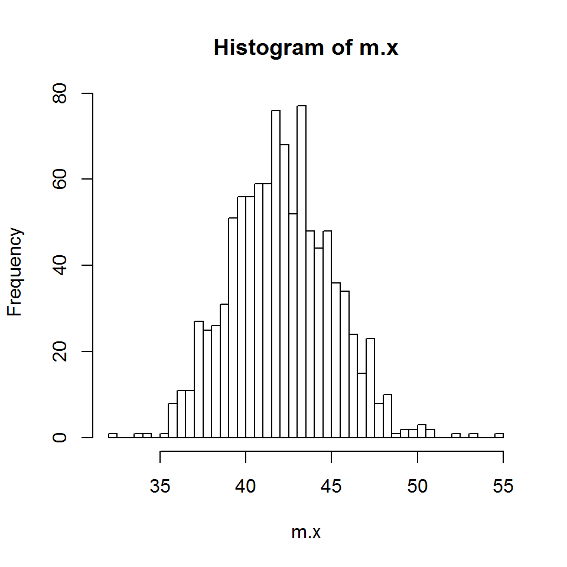

```r
B<-1000
m.x<-c(1:B)
for(i in 1:B)
{
x.boot<-sample(x,n,replace=TRUE)
m.x[i]<-mean(x.boot)
}
hist(m.x,nclass=50)
```

A Jackknife procedure for the airquality data is implmented using a loop in which at each setp one observation is left out of the data.

```r
mean(x)
```

```
## [1] 42.12931
```

```r
n <- length(x)
var(x)/n
```

```
## [1] 9.381039
```

```r
m.boot <- m.jack <- c(1:n)
 for(i in 1:n) {
    cat(i)
    x.jack <- x[ - c(i)]
    m.jack[i] <- mean(x.jack)
    x.boot <- sample(x, size = n, replace = T)
    m.boot[i] <- mean(x.boot)
}
```

```
## 123456789101112131415161718192021222324252627282930313233343…
```

Distributions of the bootstrap and jackknife replicates. Note that for the jackknife we did not include yet the inflation factor.

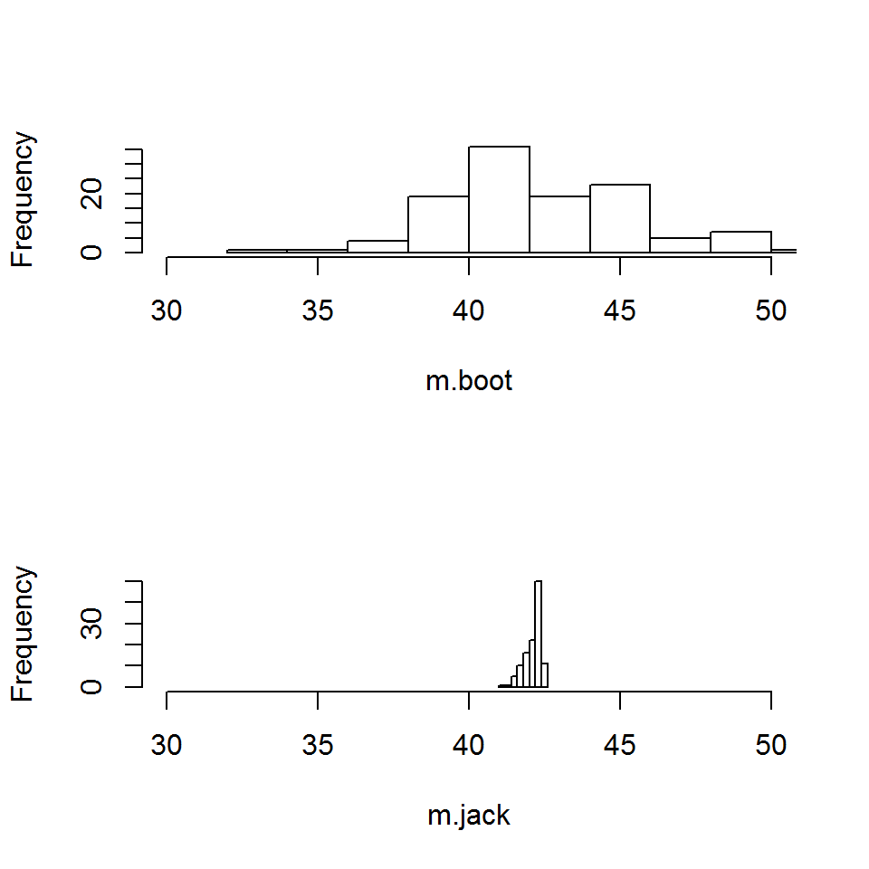

```r
par(mfrow=c(2,1))
hist(m.boot,nclass=10,xlim=c(30,50),main=" ")
hist(m.jack,nclass=10,xlim=c(30,50),main=" ")
```

Distributions of the (centered) bootstrap and jackknife replicates. Note that for this Figure, the the inflation factor is included for the jackknife replicates in the lower panel but not in the middle panel.

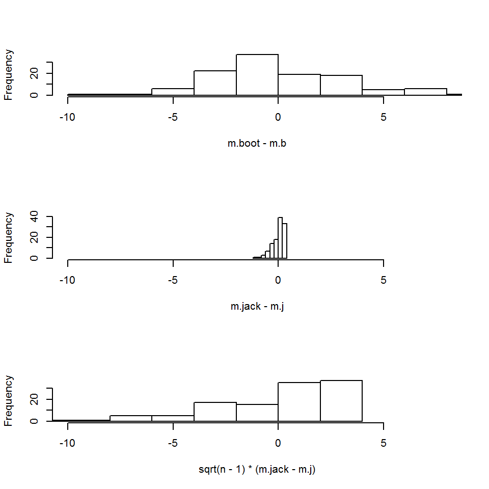

```r
m.b<-mean(m.boot)
m.j<-mean(m.jack)
par(mfrow=c(3,1))
hist(m.boot-m.b,nclass=10,main=" ",xlim=c(-10,8))
hist(m.jack-m.j,nclass=10,main=" ",xlim=c(-10,8))
hist(sqrt(n-1)*(m.jack-m.j),nclass=10,main=" ",xlim=c(-10,8))
```

## 17.3 Example: the patch data

```r
z<-patch$z
y<-patch$y
theta.obs <- mean(y)/mean(z)
```

The observed ratio is equal to

```r
theta.obs
```

```
## [1] -0.0713061
```

The jackknife procedure for the patch data.

```r
n <- length(z)
m.jack <- c(1:n)
for(i in 1:n) {
    cat(i)
    z.jack <- z[ - c(i)]
    y.jack <- y[ - c(i)]
    m.jack[i] <- mean(y.jack)/mean(z.jack)
}
```

```
## 12345678
```

The jackknife estimate for the bias:

```r
(n - 1) * (mean(m.jack) - theta.obs)
```

```
## [1] 0.008002488
```

Note that we need to include the inflation factor to calculate the bias.

# 18 Cross validation

## 18.1 Cross validation for prediction

One problem related to prediction is the fact that the data is used twice: to estimate the model and to predict the response. This can lead to an under estimation of the error that will be made when we predict the response of interest. One procedure that can be used to overcome this problem is cross validation, which consists of separating a portion of the data that we will call testing set and leave the remaining part of the dataset for training. The model is built using the training set alone and model assessment is done using the testing set alone.This procedure requires a large initial dataset and, even then, it seems unnatural to discard a part of the dataset for training since it will reduce the performance of the method.An alternative technique that improves on this is called $K$ -fold cross validation procedure that consists of the following steps: * Split the sample into $K$ equal parts. * For the $k$th part, fit the model to the other $K-1$ parts and calculate the prediction error of  
the fitted model when prediction is done on the $k$th part. * Repeat for$ k=1,2,..,K$. Leave-one-out cross validation (LOOCV) is a $K$-fold cross validation for which $K=n$ . This implies that $n$ separate times, one observation is left out and the model is trained on $n-1$ observations and evaluated on the observation that left out.

## 18.2 Example: the hormone data

The hormone data gives information about the amount in milligrams of anti-inflammatory hormone remaining in 27 devices, after a certain number of hours (hrs) of wear.

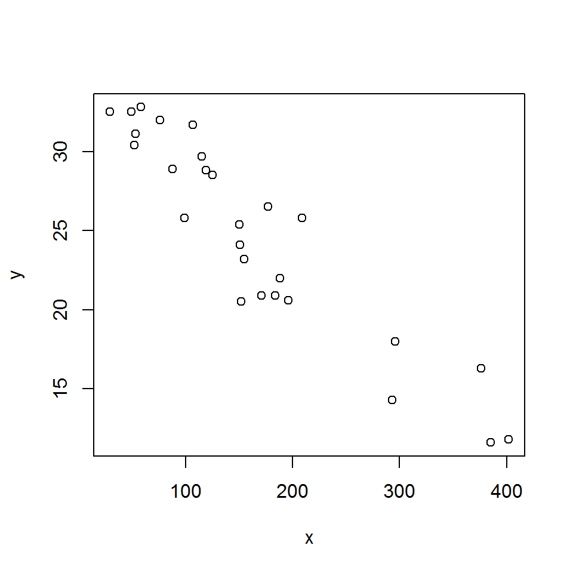

```r
y<-hormone$amount
x<-hormone$hrs
plot(x,y)
```

A linear regression model was fitted with the amount anti-inflammatory hormone as a response.

```r
fit.lm<-lm(y~x)
summary(fit.lm)
```

```
##
## Call:
## lm(formula = y ~ x)
##
## Residuals:
##     Min      1Q  Median      3Q     Max
## -4.9357 -1.7282 -0.0229  1.7388  3.7323
##
## Coefficients:
##              Estimate Std. Error t value Pr(>|t|)
## (Intercept) 34.167528   0.867197   39.40  < 2e-16 ***
## x           -0.057446   0.004464  -12.87 1.58e-12 ***
## ---
## Signif. codes:  0 '***' 0.001 '**' 0.01 '*' 0.05 '.' 0.1 ' ' 1
##
## Residual standard error: 2.378 on 25 degrees of freedom
## Multiple R-squared:  0.8688, Adjusted R-squared:  0.8636
## F-statistic: 165.6 on 1 and 25 DF,  p-value: 1.584e-12
```

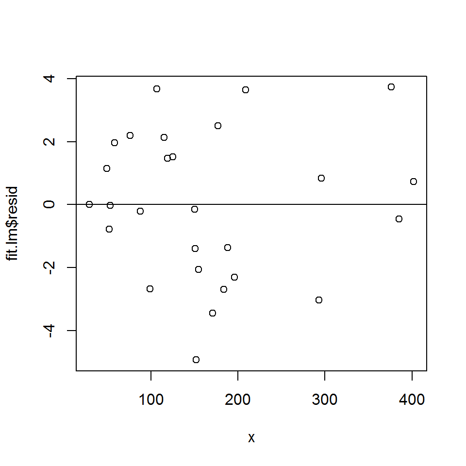

```r
plot(x,fit.lm$resid)
abline(0,0)
```

## Leave one out CV for the hormone data

We implement a leave one out cross validation for the hormone dataset. At each step, one observation is left out and the regression model is fitted to the $n-1$ observations. The cross validated residual is calculated for the observation that left out.

```r
n <- length(x)
beta.cv <- fit.cv <- c(1:n)
for(i in 1:n) {
    cat(i)
    x.cv <- x[ - c(i)]
    y.cv <- y[ - c(i)]
    fit.lm.cv <- lm(y.cv ~ x.cv)
    fit.cv[i] <- fit.lm.cv$coeff[1] + fit.lm.cv$coeff[2]*x[i]
    beta.cv[i] <- fit.lm.cv$coeff[2]
}
```

```
## 123456789101112131415161718192021222324252627
```

```r
res.cv <- y - fit.cv
cv.score <- sqrt(sum((res.cv^2))/n)
cv.score
```

```
## [1] 2.455137
```

```r
cv.score/(sqrt(sum((y - fit.lm$fit)^2)/27))
```

```
## [1] 1.072869
```

OLS residuals and CV residuals are shown below.

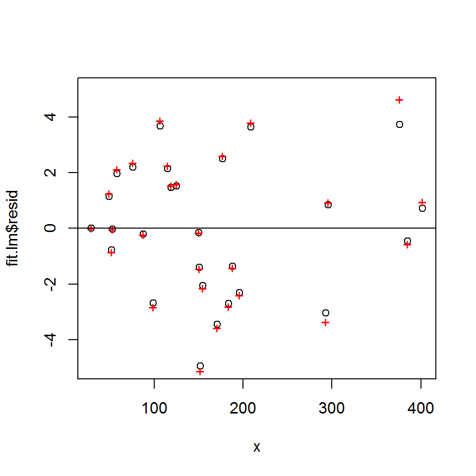

```r
plot(x,fit.lm$resid,ylim=c(-5,5))
points(x,res.cv,pch="+",col=2)
abline(0,0)
```

Parameter estimate for the slope obtained within the LOOCV procedure.

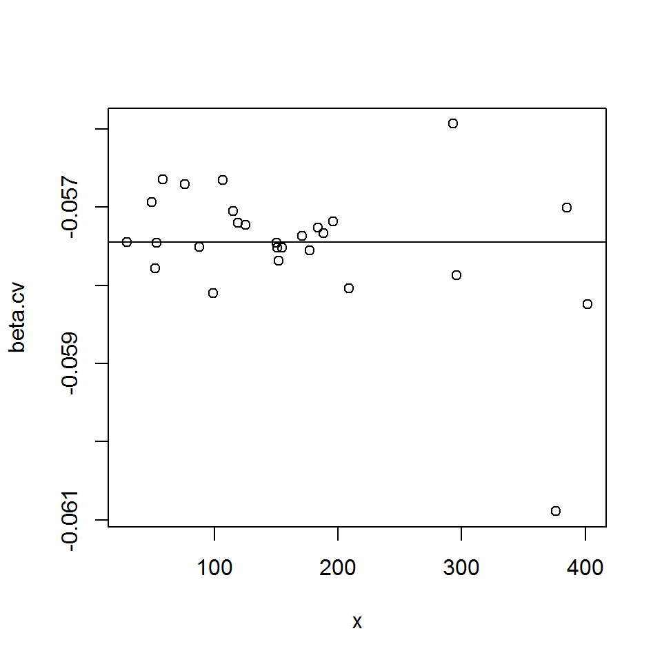

```r
plot(x,beta.cv)
abline(fit.lm$coeff[2],0)
```

Observation 10, $(x_{10},y_{10})$

```r
c(x[10],y[10])
```

```
## [1] 376.0  16.3
```

Illustration of leave out observation 10 from the data and fitting the linear model, with and without observation 10.

```r
plot(x,y)
lines(x,fit.lm$fit)
x.10<-x[-c(10)]
y.10<-y[-c(10)]
points(x.10,y.10,col=2)
fit.lm.10<-lm(y.10~x.10)
summary(fit.lm.10)
```

```
##
## Call:
## lm(formula = y.10 ~ x.10)
##
## Residuals:
##     Min      1Q  Median      3Q     Max
## -4.8090 -1.7622 -0.1338  1.6717  3.9617
##
## Coefficients:
##              Estimate Std. Error t value Pr(>|t|)
## (Intercept) 34.564057   0.857131   40.33  < 2e-16 ***
## x.10        -0.060889   0.004666  -13.05 2.16e-12 ***
## ---
## Signif. codes:  0 '***' 0.001 '**' 0.01 '*' 0.05 '.' 0.1 ' ' 1
##
## Residual standard error: 2.274 on 24 degrees of freedom
## Multiple R-squared:  0.8765, Adjusted R-squared:  0.8713
## F-statistic: 170.3 on 1 and 24 DF,  p-value: 2.158e-12
```

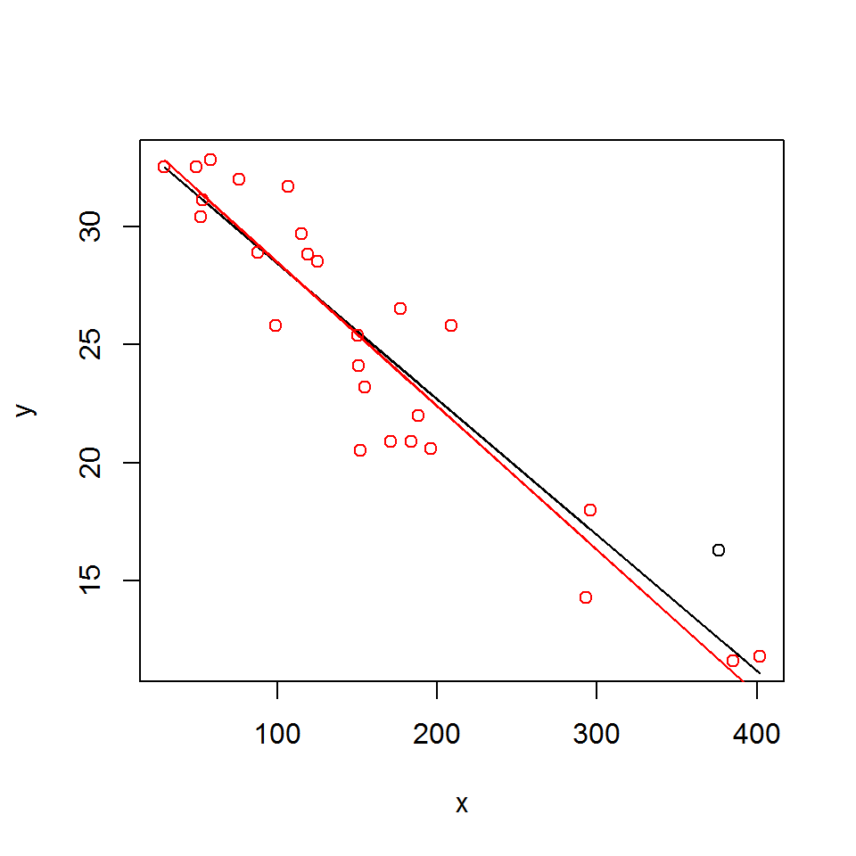

```r
lines(x.10,fit.lm.10$fit,col=2)
```

# 19 Non parametric regression

## 19.1 Example: the fuel data

The fuel dataset gives information on cars taken from the April, 1990 issue of Consumer Reports and consists of two variables:

- The mileage: a numeric vector of gas mileage in miles/gallon as tested by CU.
- Weight: a numeric vector of the car’s weight.

```r
fuel.frame<-read.table('C:/projects/cim/UpdatesSlides_2017/Data/fuel.txt')
names(fuel.frame)<-c("ID","Weight","Mileage")
par(mfrow=c(1,1))
x<-fuel.frame$Weight
y<-fuel.frame$Mileage
y<-y[order(x)]
x<-sort(x)
```

## 19.2 Parametric and non parametric regression models for the fuel data

### 19.2.1 Modeling the relationship between the car’s weight and mileage

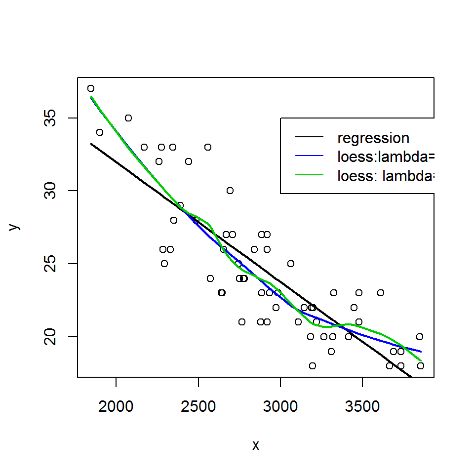

```r
plot(x,y)
fit.lm<-lm(y~x+x^2)
par(mfrow=c(1,1))
plot(x,y)
lines(x,fit.lm$fit,lwd=2)
fit.lo1<-loess(y~x)
fit.lo2<-loess(y~x,span=0.5)
lines(x,fit.lo1$fit,lwd=2,col=4)
lines(x,fit.lo2$fit,lwd=2,col=3)
legend(3000,35,c("regression","loess:lambda=0.75","loess: lambda=0.5"),col=c(1,4,3),lty=c(1,1,1))
```

We estimate the car mileage for a weight of 3200, $\hat{E}(y_{i}|x_{i}=3200$.

```r
x<-3200
newdat<-data.frame(x)
predict(fit.lm,newdat)
```

```
##        1
## 22.13231
```

```r
predict(fit.lo2,newdat)
```

```
##        1
## 20.88211
```

```r
predict(fit.lo1,newdat)
```

```
##        1
## 21.39581
```

## 19.3 Non parametric bootstrap for the fuel data

```r
x<-fuel.frame$Weight
y<-fuel.frame$Mileage
y<-y[order(x)]
x<-sort(x)
n<-length(x)
index<-c(1:n)
B<-1000
x.boot<-y.boot<-fit.b.lm<-fit.b.lo<-matrix(0,n,B)
x.b<-3000
newdat<-data.frame(x.b)
pred.lm<-pred.lo<-c(1:B)
for(i in 1:B){
cat(i)
boot.i<-sample(index,n,replace=T)
x.b<-x[boot.i]
y.b<-y[boot.i]
y.b<-y.b[order(x.b)]
x.b<-sort(x.b)
fit.lm.i<-lm(y.b~x.b+x.b^2)
fit.lo.i<-loess(y.b~x.b,span=0.5)
x.boot[,i]<-x.b
y.boot[,i]<-y.b
fit.b.lm[,i]<-fit.lm.i$fit
fit.b.lo[,i]<-fit.lo.i$fit
pred.lo[i]<-predict(fit.lo.i,newdat)
pred.lm[i]<-predict(fit.lm.i,newdat)
}
```

```
## 123456789101112131415161718192021222324252627282930313233343…
```

Data and bootstrap predicted models for the linear regression model are shown below.

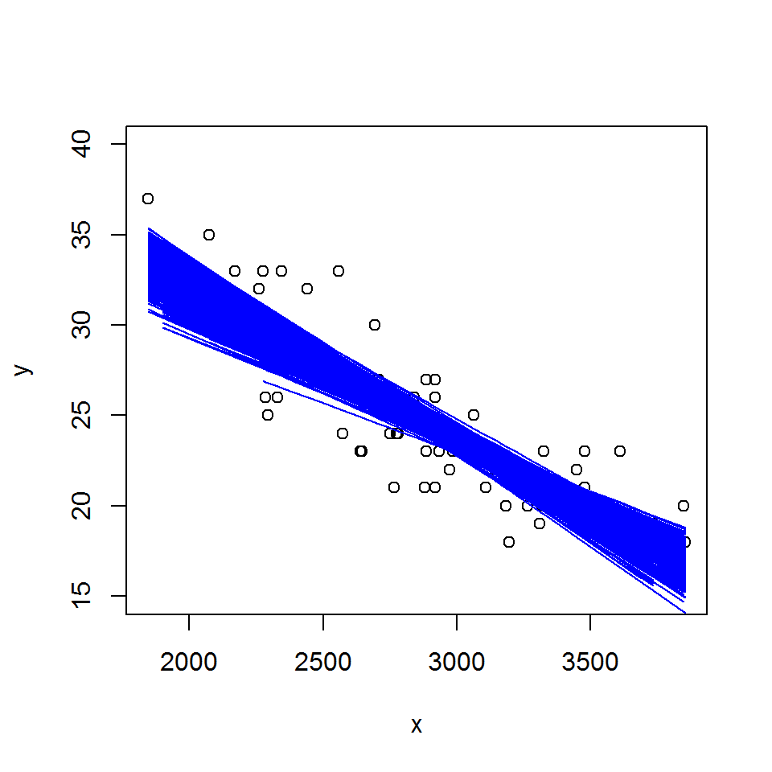

```r
plot(x,y,ylim=c(15,40))
for(i in 1:B)
{
lines(x.boot[,i],fit.b.lm[,i],col=4)
}
```

Data and bootstrap predicted models for the non parametric regression model are shown below.

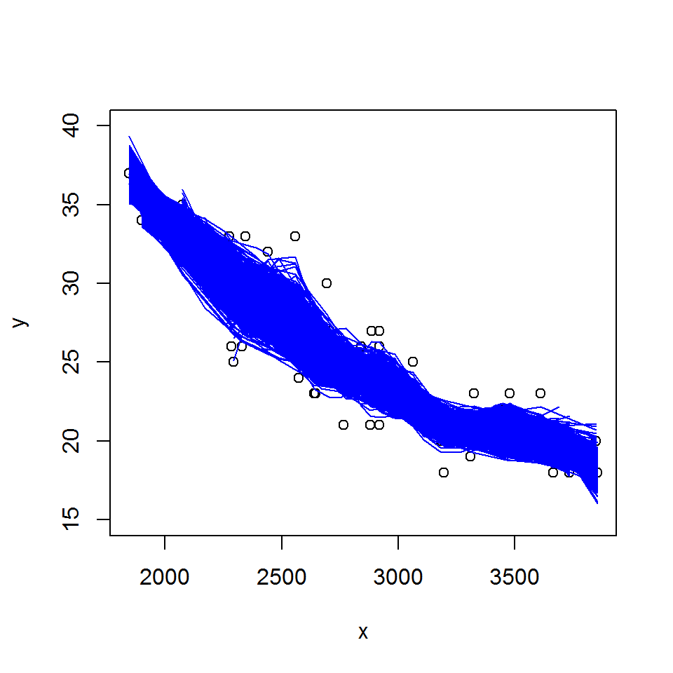

```r
plot(x,y,ylim=c(15,40))
for(i in 1:B)
{
lines(x.boot[,i],fit.b.lo[,i],col=4)
}
```

## 19.4 Prediction and C.I for the predicted values

```r
var(pred.lm)
```

```
## [1] 0.09737512
```

```r
var(pred.lo)
```

```
## [1] 0.4118891
```

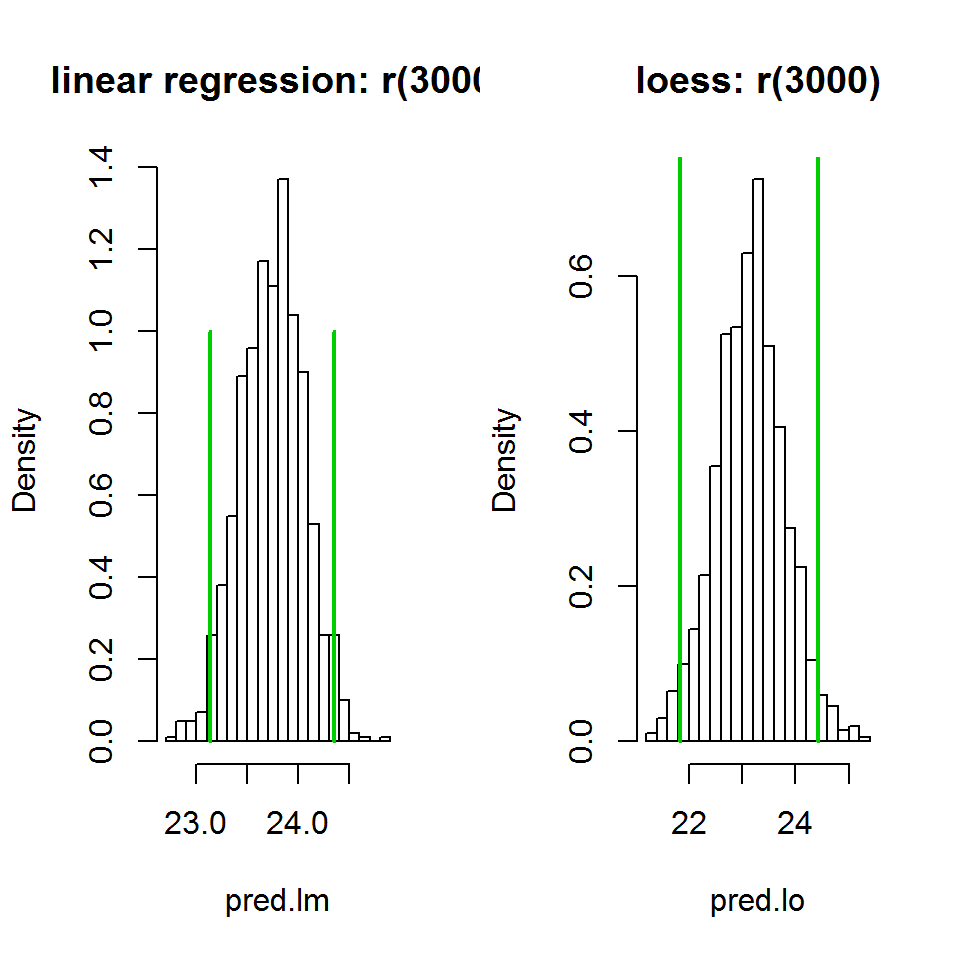

```r
cir<-quantile(pred.lm,probs=c(0.025,0.975))
cilo<-quantile(pred.lo,probs=c(0.025,0.975))
par(mfrow=c(1,2))
hist(pred.lm,col=0,nclass=25,probability=T,main=" ")
lines(c(cir[1],cir[1]),c(0,1),lwd=2,col=3)
lines(c(cir[2],cir[2]),c(0,1),lwd=2,col=3)
title("linear regression: r(3000)")
hist(pred.lo,col=0,nclass=25,probability=T,main=" ")
lines(c(cilo[1],cilo[1]),c(0,1),lwd=2,col=3)
lines(c(cilo[2],cilo[2]),c(0,1),lwd=2,col=3)
title("loess: r(3000)")
```

```r
cir
```

```
##     2.5%    97.5%
## 23.13635 24.34764
```

```r
cilo
```

```
##     2.5%    97.5%
## 21.83791 24.43009
```

# 20 Non parametric regression (II)

## 20.1 The airquality data

The air quality data gives information about the daily air quality measurements in New York, May to September 1973. For the analysis presented in this chapter we focus on the mean ozone in parts per billion from 1300 to 1500 hours at Roosevelt Island (the response) and the average wind speed in miles per hour at 0700 and 1000 hours at LaGuardia Airport (predictor). Data ($n=111$) are shown below.

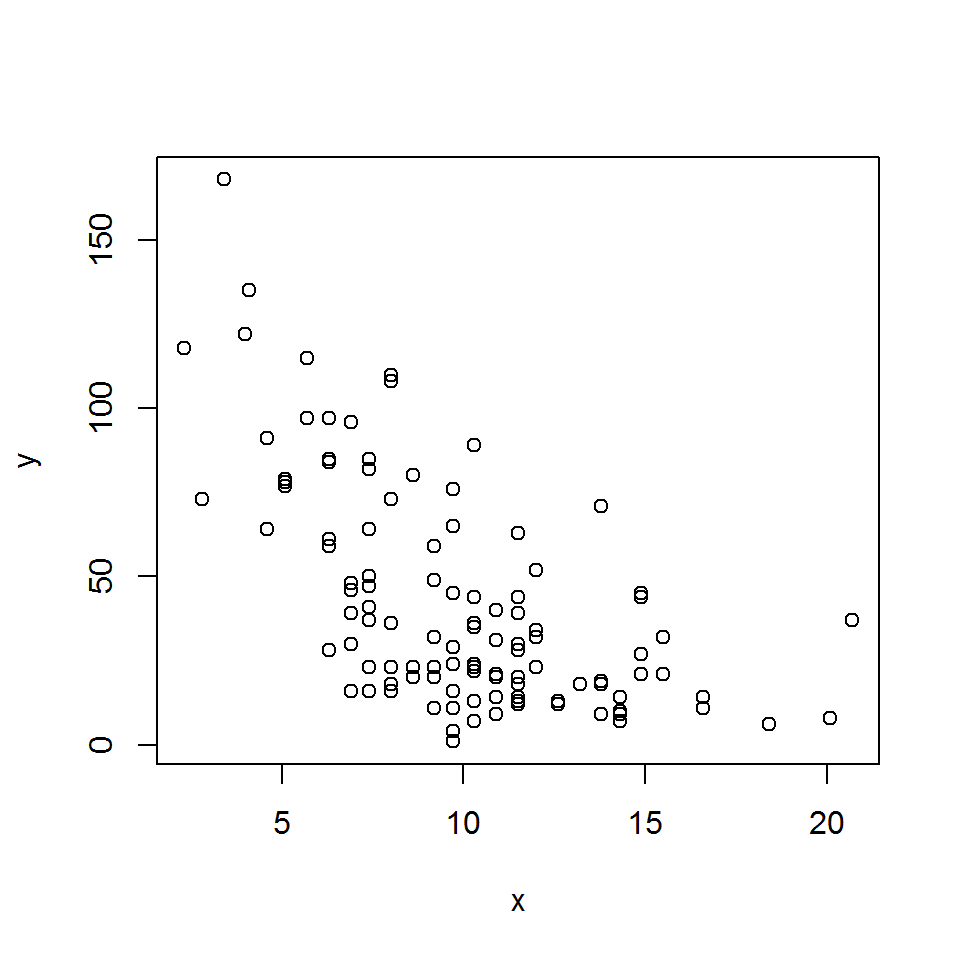

```r
xxx<-na.omit(airquality)
y<-xxx$Ozone
x<-xxx$Wind
plot(x,y)
```

We specify two model that describe the relationship between the wind speed and the ozone level,

$$\begin{array}{l}
H_{0}:E(y_{i}|x_{i})=constat,\\
H_{1}: E(y_{i}|x_{i})=r(x_{i}).
\end{array}$$

Here, $r(x)$ is a smooth function of $x$. The model spesficyed under the null hypothesis assume that $x$ does not have an effect on $y$.

## 20.2 Non parametric model under $H_{0}$

We wish to construct a confidence band under the null Model. This can be done by resampling the ozone levels $y$ and fix the wind speed $x$. We use a loess model to estimate $E(y^{*}|x)$.

```r
nx<-length(x)
B<-1000
nx
```

```
## [1] 111
```

```r
boot.x<-boot.fit<-matrix(0,length(x),B)
for(i in 1:B)
{
#x.boot<-sample(x, size=nx, replace=T)
y.boot<-sample(y, size=nx, replace=T)
boot.lo<-loess(y.boot ~ x, degree = 1, span = 0.75)
boot.fit[,i]<-boot.lo$fit
#boot.x[,i]<-x.boot
}
```

Next we smooth the data and plot the data, the estimated model and the models that were estimated under the null hypothesis.

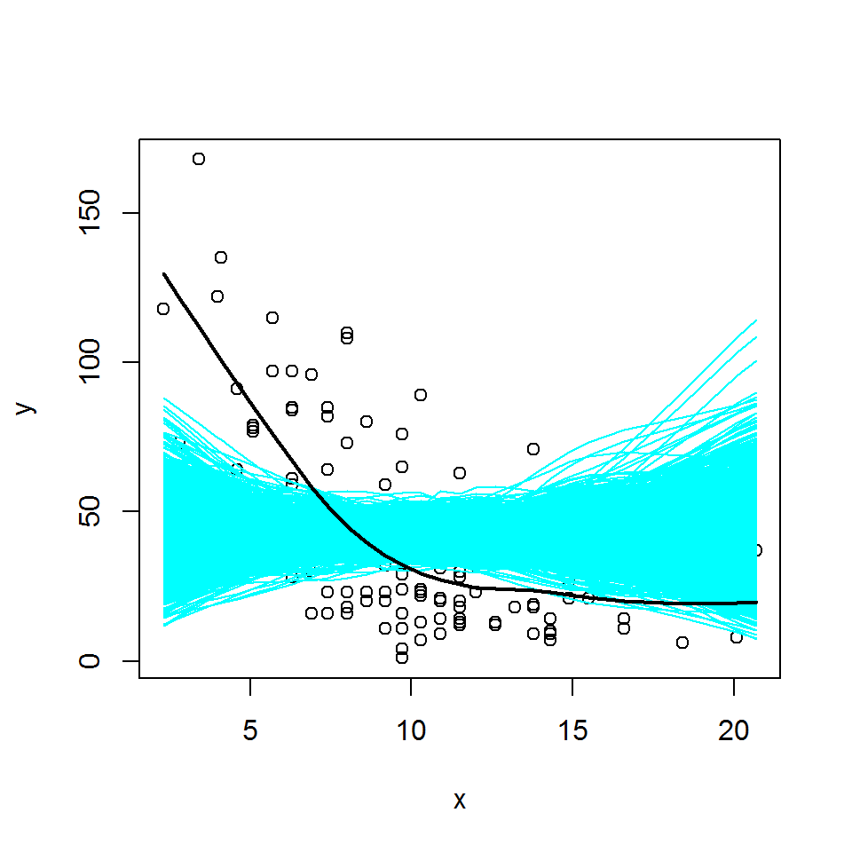

```r
par(mfrow=c(1,1))
plot(x,y)
fit.lo<-loess(y~x)
lines(sort(x),fit.lo$fit[order(x)],lwd=2)
for(i in 1:B)
{
#lines(sort(boot.x[,i]),boot.fit[,i][order(boot.x[,i])],col=5)
lines(sort(x),boot.fit[,i][order(x)],col=5)
}
lines(sort(x),fit.lo$fit[order(x)],lwd=2)
```

Ziv Shkedy  
Hasselt University, Belgium

May, 14, 2020